# Homework3

```r
getwd()
```

```r
library(data.table)
library(lubridate, quietly=TRUE)
library(zoo, quietly = TRUE)
library(dplyr, quietly = TRUE)
library(glmnet)
library(MLmetrics)
library("mvtnorm")
library(tidyr)
library(ggplot2)
```

```r
dt=fread("GercekZamanliTuketim-01012016-01122020.csv")
dt$Tarih=dmy(dt$Tarih)
```

```r
setnames(dt, "Tüketim Miktarı (MWh)", "consumption")
setnames(dt, "Tarih", "date")
setnames(dt, "Saat", "hour")
dt$consumption=gsub('\\.', '', dt$consumption)
dt$consumption=gsub('\\,', '.', dt$consumption)
dt$hour=gsub(':00', '', dt$hour)
```

```r
dt$consumption=as.numeric(dt$consumption)
dt$hour=as.numeric(dt$hour)
str(dt)
```

```
Classes 'data.table' and 'data.frame':	43128 obs. of  3 variables:
 $ date       : Date, format: "2016-01-01" "2016-01-01" ...
 $ hour       : num  0 1 2 3 4 5 6 7 8 9 ...
 $ consumption: num  26277 24992 23533 22465 22003 ...
 - attr(*, ".internal.selfref")=<externalptr>
```

```r
dt<-dt[-2068]
```

```r
str(dt)
```

```
Classes 'data.table' and 'data.frame':	43127 obs. of  3 variables:
 $ date       : Date, format: "2016-01-01" "2016-01-01" ...
 $ hour       : num  0 1 2 3 4 5 6 7 8 9 ...
 $ consumption: num  26277 24992 23533 22465 22003 ...
 - attr(*, ".internal.selfref")=<externalptr>
```

```r
dt_lagged1=copy(dt)
dt_lagged1[, Lag_48:=shift(consumption,type="lag",n=48)]
dt_lagged1[, Lag_168:=shift(consumption,type="lag",n=168)]
```

```r
train=filter(dt_lagged1,date<="2020-10-31")
#train
```

```r
test=filter(dt_lagged1,date>"2020-10-31")
#test
```

```r
MAPE_48=MAPE(test$consumption,test$Lag_48)
MAPE_48_values=abs(((test$consumption-test$Lag_48)/test$Lag_48))
print(paste("MAPE value for lag48 equals to:", MAPE_48))
MAPE_168=MAPE(test$consumption,test$Lag_168)
MAPE_168_values=abs(((test$consumption-test$Lag_168)/test$Lag_168))
print(paste("MAPE value for lag168 equals to:", MAPE_168))
```

```
[1] "MAPE value for lag48 equals to: 0.0818808509914842"
[1] "MAPE value for lag168 equals to: 0.0365111250910964"
```

### Summary Statistics for Lag 48 Model

```r
summary(MAPE_48_values)
```

```
     Min.   1st Qu.    Median      Mean   3rd Qu.      Max.
0.0000955 0.0166310 0.0572291 0.0818809 0.1040364 0.4467156
```

### Summary Statistics for Lag 168 Model

```r
summary(MAPE_168_values)
```

```
     Min.   1st Qu.    Median      Mean   3rd Qu.      Max.
8.522e-05 1.354e-02 2.573e-02 3.651e-02 4.766e-02 2.432e-01
```

# PART B

```r
str(train)
```

```
Classes 'data.table' and 'data.frame':	42383 obs. of  5 variables:
 $ date       : Date, format: "2016-01-01" "2016-01-01" ...
 $ hour       : num  0 1 2 3 4 5 6 7 8 9 ...
 $ consumption: num  26277 24992 23533 22465 22003 ...
 $ Lag_48     : num  NA NA NA NA NA NA NA NA NA NA ...
 $ Lag_168    : num  NA NA NA NA NA NA NA NA NA NA ...
 - attr(*, ".internal.selfref")=<externalptr>
```

```r
Reg=lm(data=train, consumption~Lag_48+Lag_168)
summary(Reg)
```

```
Call:
lm(formula = consumption ~ Lag_48 + Lag_168, data = train)

Residuals:
     Min       1Q   Median       3Q      Max
-25242.5   -985.7     -1.2   1017.1  16101.2

Coefficients:
             Estimate Std. Error t value Pr(>|t|)
(Intercept) 1.574e+03  8.355e+01   18.84   <2e-16 ***
Lag_48      3.086e-01  3.097e-03   99.64   <2e-16 ***
Lag_168     6.434e-01  3.094e-03  207.94   <2e-16 ***
---
Signif. codes:  0 '***' 0.001 '**' 0.01 '*' 0.05 '.' 0.1 ' ' 1

Residual standard error: 2392 on 42212 degrees of freedom
  (168 observations deleted due to missingness)
Multiple R-squared:  0.7752,	Adjusted R-squared:  0.7752
F-statistic: 7.278e+04 on 2 and 42212 DF,  p-value: < 2.2e-16
```

```r
predictions=predict(Reg,newdata = test)
MAPE_reg=MAPE(predictions,test$consumption)
MAPE_reg_values=as.vector(abs(((test$consumption-predictions)/test$consumption)))
print(paste("MAPE value for autoregression model equals to:", MAPE_reg))
```

```
[1] "MAPE value for autoregression model equals to: 0.0423023288459373"
```

### Summary Statistics for Time Series Regression Model

```r
summary(MAPE_reg_values)
```

```
     Min.   1st Qu.    Median      Mean   3rd Qu.      Max.
3.669e-05 1.827e-02 3.309e-02 4.230e-02 5.706e-02 1.661e-01
```

# PART C

## Data Preparation

All datasets are constructed by considering the hour information. There are 24 models for prediction.

```r
names_train<-paste0("hour",0:23,"_train")
names_test<-paste0("hour",0:23,"_test")
```

```r
train_split <- split(train, train$hour)
new_names_train <- names_train
for (i in 1:length(train_split)) {
  assign(new_names_train[i], train_split[[i]])
}
```

```r
test_split <- split(test, test$hour)
new_names_test <- names_test
for (i in 1:length(test_split)) {
  assign(new_names_test[i], test_split[[i]])
}
```

## Models

```r
mape_result_c=rep(0,24)
```

## Model for Hour 0

```r
Reg0=lm(data=hour0_train, consumption~Lag_48+Lag_168)
summary(Reg0)
predictions0=predict(Reg0,newdata = hour0_test)
MAPE_0=MAPE(predictions0,hour0_test$consumption)
MAPE_0_values=as.vector(abs((hour0_test$consumption-predictions0)/length(test$consumption)))
MAPE0c_reg_values=as.vector(abs(((hour0_test$consumption-predictions0)/hour0_test$consumption)))
mape_result_c[1]<-MAPE_0
MAPE_0
```

```
Call:
lm(formula = consumption ~ Lag_48 + Lag_168, data = hour0_train)

Residuals:
    Min      1Q  Median      3Q     Max
-9161.4  -801.5    42.1   883.4  6410.7

Coefficients:
             Estimate Std. Error t value Pr(>|t|)
(Intercept) 2.150e+03  4.325e+02    4.97 7.34e-07 ***
Lag_48      4.878e-01  1.686e-02   28.94  < 2e-16 ***
Lag_168     4.431e-01  1.685e-02   26.30  < 2e-16 ***
---
Signif. codes:  0 '***' 0.001 '**' 0.01 '*' 0.05 '.' 0.1 ' ' 1

Residual standard error: 1592 on 1756 degrees of freedom
  (7 observations deleted due to missingness)
Multiple R-squared:  0.7205,	Adjusted R-squared:  0.7202
F-statistic:  2263 on 2 and 1756 DF,  p-value: < 2.2e-16
```

0.0326781573641774

### Summary Statistics for Hour 0

```r
summary(MAPE0c_reg_values)
```

```
    Min.  1st Qu.   Median     Mean  3rd Qu.     Max.
0.009225 0.018975 0.031534 0.032678 0.045920 0.067888
```

## Model for Hour 1

```r
Reg1=lm(data=hour1_train, consumption~Lag_48+Lag_168)
summary(Reg1)
predictions1=predict(Reg1,newdata = hour1_test)
MAPE_1=MAPE(predictions1,hour1_test$consumption)
MAPE_1_values=as.vector(abs((hour1_test$consumption-predictions1)/length(test$consumption)))
MAPE1c_reg_values=as.vector(abs(((hour1_test$consumption-predictions1)/hour1_test$consumption)))
mape_result_c[2]<-MAPE_1
MAPE_1
```

```
Call:
lm(formula = consumption ~ Lag_48 + Lag_168, data = hour1_train)

Residuals:
    Min      1Q  Median      3Q     Max
-9386.4  -776.2    76.1   832.4  6461.9

Coefficients:
             Estimate Std. Error t value Pr(>|t|)
(Intercept) 2.086e+03  4.139e+02   5.039 5.15e-07 ***
Lag_48      4.926e-01  1.687e-02  29.204  < 2e-16 ***
Lag_168     4.369e-01  1.685e-02  25.923  < 2e-16 ***
---
Signif. codes:  0 '***' 0.001 '**' 0.01 '*' 0.05 '.' 0.1 ' ' 1

Residual standard error: 1562 on 1756 degrees of freedom
  (7 observations deleted due to missingness)
Multiple R-squared:  0.7167,	Adjusted R-squared:  0.7164
F-statistic:  2221 on 2 and 1756 DF,  p-value: < 2.2e-16
```

0.0328606728370167

### Summary Statistics for Hour 1

```r
summary(MAPE1c_reg_values)
```

```
    Min.  1st Qu.   Median     Mean  3rd Qu.     Max.
0.001582 0.020248 0.030097 0.032861 0.045811 0.075048
```

## Model for Hour 2

```r
Reg2=lm(data=hour2_train, consumption~Lag_48+Lag_168)
summary(Reg2)
predictions2=predict(Reg2,newdata = hour2_test)
MAPE_2=MAPE(predictions2,hour2_test$consumption)
MAPE_2_values=as.vector(abs((hour2_test$consumption-predictions2)/length(test$consumption)))
MAPE2c_reg_values=as.vector(abs(((hour2_test$consumption-predictions2)/hour2_test$consumption)))
mape_result_c[3]<-MAPE_2
MAPE_2
```

```
Call:
lm(formula = consumption ~ Lag_48 + Lag_168, data = hour2_train)

Residuals:
     Min       1Q   Median       3Q      Max
-25291.0   -799.0     78.7    871.1   6350.5

Coefficients:
             Estimate Std. Error t value Pr(>|t|)
(Intercept) 1.950e+03  4.407e+02   4.424 1.03e-05 ***
Lag_48      4.987e-01  1.823e-02  27.354  < 2e-16 ***
Lag_168     4.323e-01  1.820e-02  23.756  < 2e-16 ***
---
Signif. codes:  0 '***' 0.001 '**' 0.01 '*' 0.05 '.' 0.1 ' ' 1

Residual standard error: 1660 on 1756 degrees of freedom
  (7 observations deleted due to missingness)
Multiple R-squared:  0.6748,	Adjusted R-squared:  0.6745
F-statistic:  1822 on 2 and 1756 DF,  p-value: < 2.2e-16
```

0.0341566699918791

### Summary Statistics for Hour 2

```r
summary(MAPE2c_reg_values)
```

```
    Min.  1st Qu.   Median     Mean  3rd Qu.     Max.
0.001649 0.021411 0.033975 0.034157 0.045180 0.066947
```

## Model for Hour 3

```r
Reg3=lm(data=hour3_train, consumption~Lag_48+Lag_168)
summary(Reg3)
predictions3=predict(Reg3,newdata = hour3_test)
MAPE_3=MAPE(predictions3,hour3_test$consumption)
MAPE_3_values=as.vector(abs((hour3_test$consumption-predictions3)/length(test$consumption)))
MAPE3c_reg_values=as.vector(abs(((hour3_test$consumption-predictions3)/hour3_test$consumption)))
mape_result_c[4]<-MAPE_3
MAPE_3
```

```
Call:
lm(formula = consumption ~ Lag_48 + Lag_168, data = hour3_train)

Residuals:
    Min      1Q  Median      3Q     Max
-8891.9  -830.3    63.5   836.8 12046.2

Coefficients:
             Estimate Std. Error t value Pr(>|t|)
(Intercept) 3.041e+03  4.113e+02   7.394 2.19e-13 ***
Lag_48      4.697e-01  1.659e-02  28.311  < 2e-16 ***
Lag_168     4.212e-01  1.656e-02  25.433  < 2e-16 ***
---
Signif. codes:  0 '***' 0.001 '**' 0.01 '*' 0.05 '.' 0.1 ' ' 1

Residual standard error: 1564 on 1755 degrees of freedom
  (7 observations deleted due to missingness)
Multiple R-squared:  0.6742,	Adjusted R-squared:  0.6738
F-statistic:  1816 on 2 and 1755 DF,  p-value: < 2.2e-16
```

0.0320678737328794

### Summary Statistics for Hour 3

```r
summary(MAPE3c_reg_values)
```

```
    Min.  1st Qu.   Median     Mean  3rd Qu.     Max.
0.002293 0.019134 0.025323 0.032068 0.042729 0.064820
```

## Model for Hour 4

```r
Reg4=lm(data=hour4_train, consumption~Lag_48+Lag_168)
summary(Reg4)
predictions4=predict(Reg4,newdata = hour4_test)
MAPE_4=MAPE(predictions4,hour4_test$consumption)
MAPE_4_values=as.vector(abs((hour4_test$consumption-predictions4)/length(test$consumption)))
MAPE4c_reg_values=as.vector(abs(((hour4_test$consumption-predictions4)/hour4_test$consumption)))
mape_result_c[5]<-MAPE_4
MAPE_4
```

```
Call:
lm(formula = consumption ~ Lag_48 + Lag_168, data = hour4_train)

Residuals:
    Min      1Q  Median      3Q     Max
-7887.3  -805.0    40.2   861.5  6287.3

Coefficients:
             Estimate Std. Error t value Pr(>|t|)
(Intercept) 2.207e+03  4.098e+02   5.385 8.24e-08 ***
Lag_48      4.747e-01  1.696e-02  27.980  < 2e-16 ***
Lag_168     4.449e-01  1.691e-02  26.302  < 2e-16 ***
---
Signif. codes:  0 '***' 0.001 '**' 0.01 '*' 0.05 '.' 0.1 ' ' 1

Residual standard error: 1495 on 1756 degrees of freedom
  (7 observations deleted due to missingness)
Multiple R-squared:  0.6841,	Adjusted R-squared:  0.6837
F-statistic:  1901 on 2 and 1756 DF,  p-value: < 2.2e-16
```

0.0318298166936024

### Summary Statistics for Hour 4

```r
summary(MAPE4c_reg_values)
```

```
     Min.   1st Qu.    Median      Mean   3rd Qu.      Max.
0.0007094 0.0195199 0.0314371 0.0318298 0.0416672 0.0642227
```

## Model for Hour 5

```r
Reg5=lm(data=hour5_train, consumption~Lag_48+Lag_168)
summary(Reg5)
predictions5=predict(Reg5,newdata = hour5_test)
MAPE_5=MAPE(predictions5,hour5_test$consumption)
MAPE_5_values=as.vector(abs((hour5_test$consumption-predictions5)/length(test$consumption)))
MAPE5c_reg_values=as.vector(abs(((hour5_test$consumption-predictions5)/hour5_test$consumption)))
mape_result_c[6]<-MAPE_5
MAPE_5
```

```
Call:
lm(formula = consumption ~ Lag_48 + Lag_168, data = hour5_train)

Residuals:
    Min      1Q  Median      3Q     Max
-7438.8  -778.2    34.5   839.2  6380.5

Coefficients:
             Estimate Std. Error t value Pr(>|t|)
(Intercept) 2.225e+03  4.192e+02   5.308 1.25e-07 ***
Lag_48      4.398e-01  1.689e-02  26.043  < 2e-16 ***
Lag_168     4.785e-01  1.685e-02  28.405  < 2e-16 ***
---
Signif. codes:  0 '***' 0.001 '**' 0.01 '*' 0.05 '.' 0.1 ' ' 1

Residual standard error: 1486 on 1756 degrees of freedom
  (7 observations deleted due to missingness)
Multiple R-squared:  0.6705,	Adjusted R-squared:  0.6701
F-statistic:  1787 on 2 and 1756 DF,  p-value: < 2.2e-16
```

0.0318737009684422

### Summary Statistics for Hour 5

```r
summary(MAPE5c_reg_values)
```

```
    Min.  1st Qu.   Median     Mean  3rd Qu.     Max.
0.002724 0.019877 0.028510 0.031874 0.046308 0.063261
```

## Model for Hour 6

```r
Reg6=lm(data=hour6_train, consumption~Lag_48+Lag_168)
summary(Reg6)
predictions6=predict(Reg6,newdata = hour6_test)
MAPE_6=MAPE(predictions6,hour6_test$consumption)
MAPE_6_values=as.vector(abs((hour6_test$consumption-predictions6)/length(test$consumption)))
MAPE6c_reg_values=as.vector(abs(((hour6_test$consumption-predictions6)/hour6_test$consumption)))
mape_result_c[7]<-MAPE_6
MAPE_6
```

```
Call:
lm(formula = consumption ~ Lag_48 + Lag_168, data = hour6_train)

Residuals:
    Min      1Q  Median      3Q     Max
-7425.2  -730.8    38.1   849.2  7051.5

Coefficients:
             Estimate Std. Error t value Pr(>|t|)
(Intercept) 2.119e+03  4.248e+02   4.988 6.71e-07 ***
Lag_48      3.760e-01  1.651e-02  22.771  < 2e-16 ***
Lag_168     5.464e-01  1.649e-02  33.140  < 2e-16 ***
---
Signif. codes:  0 '***' 0.001 '**' 0.01 '*' 0.05 '.' 0.1 ' ' 1

Residual standard error: 1565 on 1756 degrees of freedom
  (7 observations deleted due to missingness)
Multiple R-squared:  0.6703,	Adjusted R-squared:  0.6699
F-statistic:  1785 on 2 and 1756 DF,  p-value: < 2.2e-16
```

0.0314791367625476

### Summary Statistics for Hour 6

```r
summary(MAPE6c_reg_values)
```

```
    Min.  1st Qu.   Median     Mean  3rd Qu.     Max.
0.001469 0.012045 0.028691 0.031479 0.051667 0.067635
```

## Model for Hour 7

```r
Reg7=lm(data=hour7_train, consumption~Lag_48+Lag_168)
summary(Reg7)
predictions7=predict(Reg7,newdata = hour7_test)
MAPE_7=MAPE(predictions7,hour7_test$consumption)
MAPE_7_values=as.vector(abs((hour7_test$consumption-predictions7)/length(test$consumption)))
MAPE7c_reg_values=as.vector(abs(((hour7_test$consumption-predictions7)/hour7_test$consumption)))
mape_result_c[8]<-MAPE_7
MAPE_7
```

```
Call:
lm(formula = consumption ~ Lag_48 + Lag_168, data = hour7_train)

Residuals:
    Min      1Q  Median      3Q     Max
-8818.6  -809.1    61.4   929.9  8945.6

Coefficients:
             Estimate Std. Error t value Pr(>|t|)
(Intercept) 2.376e+03  4.723e+02    5.03 5.41e-07 ***
Lag_48      2.661e-01  1.570e-02   16.95  < 2e-16 ***
Lag_168     6.509e-01  1.565e-02   41.59  < 2e-16 ***
---
Signif. codes:  0 '***' 0.001 '**' 0.01 '*' 0.05 '.' 0.1 ' ' 1

Residual standard error: 1917 on 1756 degrees of freedom
  (7 observations deleted due to missingness)
Multiple R-squared:  0.6535,	Adjusted R-squared:  0.6531
F-statistic:  1656 on 2 and 1756 DF,  p-value: < 2.2e-16
```

0.0377669297128062

### Summary Statistics for Hour 7

```r
summary(MAPE7c_reg_values)
```

```
    Min.  1st Qu.   Median     Mean  3rd Qu.     Max.
0.003466 0.018366 0.036097 0.037767 0.049894 0.092366
```

## Model for Hour 8

```r
Reg8=lm(data=hour8_train, consumption~Lag_48+Lag_168)
summary(Reg8)
predictions8=predict(Reg8,newdata = hour8_test)
MAPE_8=MAPE(predictions8,hour8_test$consumption)
MAPE_8_values=as.vector(abs((hour8_test$consumption-predictions8)/length(test$consumption)))
MAPE8c_reg_values=as.vector(abs(((hour8_test$consumption-predictions8)/hour8_test$consumption)))
mape_result_c[9]<-MAPE_8
MAPE_8
```

```
Call:
lm(formula = consumption ~ Lag_48 + Lag_168, data = hour8_train)

Residuals:
     Min       1Q   Median       3Q      Max
-13437.6  -1026.7    132.3   1185.9  13039.3

Coefficients:
             Estimate Std. Error t value Pr(>|t|)
(Intercept) 3.381e+03  6.050e+02   5.589 2.65e-08 ***
Lag_48      1.730e-01  1.523e-02  11.365  < 2e-16 ***
Lag_168     7.220e-01  1.517e-02  47.579  < 2e-16 ***
---
Signif. codes:  0 '***' 0.001 '**' 0.01 '*' 0.05 '.' 0.1 ' ' 1

Residual standard error: 2717 on 1756 degrees of freedom
  (7 observations deleted due to missingness)
Multiple R-squared:  0.6155,	Adjusted R-squared:  0.6151
F-statistic:  1406 on 2 and 1756 DF,  p-value: < 2.2e-16
```

0.046774711470155

### Summary Statistics for Hour 8

```r
summary(MAPE8c_reg_values)
```

```
     Min.   1st Qu.    Median      Mean   3rd Qu.      Max.
0.0004843 0.0263494 0.0391519 0.0467747 0.0675130 0.1284437
```

## Model for Hour 9

```r
Reg9=lm(data=hour9_train, consumption~Lag_48+Lag_168)
summary(Reg9)
predictions9=predict(Reg9,newdata = hour9_test)
MAPE_9=MAPE(predictions9,hour9_test$consumption)
MAPE_9_values=as.vector(abs((hour9_test$consumption-predictions9)/length(test$consumption)))
MAPE9c_reg_values=as.vector(abs(((hour9_test$consumption-predictions9)/hour9_test$consumption)))
mape_result_c[10]<-MAPE_9
MAPE_9
```

```
Call:
lm(formula = consumption ~ Lag_48 + Lag_168, data = hour9_train)

Residuals:
     Min       1Q   Median       3Q      Max
-15684.4  -1304.8    118.6   1354.7  15003.9

Coefficients:
             Estimate Std. Error t value Pr(>|t|)
(Intercept) 3.650e+03  6.553e+02    5.57 2.94e-08 ***
Lag_48      1.741e-01  1.535e-02   11.34  < 2e-16 ***
Lag_168     7.195e-01  1.533e-02   46.94  < 2e-16 ***
---
Signif. codes:  0 '***' 0.001 '**' 0.01 '*' 0.05 '.' 0.1 ' ' 1

Residual standard error: 3061 on 1756 degrees of freedom
  (7 observations deleted due to missingness)
Multiple R-squared:  0.6085,	Adjusted R-squared:  0.608
F-statistic:  1365 on 2 and 1756 DF,  p-value: < 2.2e-16
```

0.0548491715526489

### Summary Statistics for Hour 9

```r
summary(MAPE9c_reg_values)
```

```
    Min.  1st Qu.   Median     Mean  3rd Qu.     Max.
0.002536 0.025265 0.050889 0.054849 0.083051 0.157453
```

## Model for Hour 10

```r
Reg10=lm(data=hour10_train, consumption~Lag_48+Lag_168)
summary(Reg10)
predictions10=predict(Reg10,newdata = hour10_test)
MAPE_10=MAPE(predictions10,hour10_test$consumption)
MAPE_10_values=as.vector(abs((hour10_test$consumption-predictions10)/length(test$consumption)))
MAPE10c_reg_values=as.vector(abs(((hour10_test$consumption-predictions10)/hour10_test$consumption)))
mape_result_c[11]<-MAPE_10
MAPE_10
```

```
Call:
lm(formula = consumption ~ Lag_48 + Lag_168, data = hour10_train)

Residuals:
     Min       1Q   Median       3Q      Max
-16524.8  -1361.2     93.2   1456.1  15547.8

Coefficients:
             Estimate Std. Error t value Pr(>|t|)
(Intercept) 3.756e+03  6.676e+02   5.626 2.14e-08 ***
Lag_48      2.061e-01  1.584e-02  13.015  < 2e-16 ***
Lag_168     6.866e-01  1.583e-02  43.378  < 2e-16 ***
---
Signif. codes:  0 '***' 0.001 '**' 0.01 '*' 0.05 '.' 0.1 ' ' 1

Residual standard error: 3079 on 1756 degrees of freedom
  (7 observations deleted due to missingness)
Multiple R-squared:  0.5953,	Adjusted R-squared:  0.5948
F-statistic:  1292 on 2 and 1756 DF,  p-value: < 2.2e-16
```

0.0608656555171933

### Summary Statistics for Hour 10

```r
summary(MAPE10c_reg_values)
```

```
   Min. 1st Qu.  Median    Mean 3rd Qu.    Max.
0.00718 0.03141 0.05529 0.06087 0.08546 0.14294
```

## Model for Hour 11

```r
Reg11=lm(data=hour11_train, consumption~Lag_48+Lag_168)
summary(Reg11)
predictions11=predict(Reg11,newdata = hour11_test)
MAPE_11=MAPE(predictions11,hour11_test$consumption)
MAPE_11_values=as.vector(abs((hour11_test$consumption-predictions11)/length(test$consumption)))
MAPE11c_reg_values=as.vector(abs(((hour11_test$consumption-predictions11)/hour11_test$consumption)))
mape_result_c[12]<-MAPE_11
MAPE_11
```

```
Call:
lm(formula = consumption ~ Lag_48 + Lag_168, data = hour11_train)

Residuals:
     Min       1Q   Median       3Q      Max
-17064.8  -1439.6     88.9   1520.9  15682.7

Coefficients:
             Estimate Std. Error t value Pr(>|t|)
(Intercept) 3964.3939   684.8797   5.788  8.4e-09 ***
Lag_48         0.2249     0.0162  13.884  < 2e-16 ***
Lag_168        0.6635     0.0162  40.961  < 2e-16 ***
---
Signif. codes:  0 '***' 0.001 '**' 0.01 '*' 0.05 '.' 0.1 ' ' 1

Residual standard error: 3128 on 1756 degrees of freedom
  (7 observations deleted due to missingness)
Multiple R-squared:  0.5817,	Adjusted R-squared:  0.5812
F-statistic:  1221 on 2 and 1756 DF,  p-value: < 2.2e-16
```

0.0627335523496044

### Summary Statistics for Hour 11

```r
summary(MAPE11c_reg_values)
```

```
     Min.   1st Qu.    Median      Mean   3rd Qu.      Max.
0.0006648 0.0305524 0.0564425 0.0627335 0.0814580 0.1478300
```

## Model for Hour 12

```r
Reg12=lm(data=hour12_train, consumption~Lag_48+Lag_168)
summary(Reg12)
predictions12=predict(Reg12,newdata = hour12_test)
MAPE_12=MAPE(predictions12,hour12_test$consumption)
MAPE_12_values=as.vector(abs((hour12_test$consumption-predictions12)/length(test$consumption)))
MAPE12c_reg_values=as.vector(abs(((hour12_test$consumption-predictions12)/hour12_test$consumption)))
mape_result_c[13]<-MAPE_12
MAPE_12
```

```
Call:
lm(formula = consumption ~ Lag_48 + Lag_168, data = hour12_train)

Residuals:
     Min       1Q   Median       3Q      Max
-15473.8  -1435.7     47.4   1514.9  14620.3

Coefficients:
             Estimate Std. Error t value Pr(>|t|)
(Intercept) 3.642e+03  6.327e+02   5.756 1.01e-08 ***
Lag_48      2.804e-01  1.664e-02  16.850  < 2e-16 ***
Lag_168     6.133e-01  1.665e-02  36.828  < 2e-16 ***
---
Signif. codes:  0 '***' 0.001 '**' 0.01 '*' 0.05 '.' 0.1 ' ' 1

Residual standard error: 2872 on 1756 degrees of freedom
  (7 observations deleted due to missingness)
Multiple R-squared:  0.591,	Adjusted R-squared:  0.5905
F-statistic:  1269 on 2 and 1756 DF,  p-value: < 2.2e-16
```

0.0654612829573795

### Summary Statistics for Hour 12

```r
summary(MAPE12c_reg_values)
```

```
    Min.  1st Qu.   Median     Mean  3rd Qu.     Max.
0.002505 0.030372 0.059841 0.065461 0.090265 0.158904
```

## Model for Hour 13

```r
Reg13=lm(data=hour13_train, consumption~Lag_48+Lag_168)
summary(Reg13)
predictions13=predict(Reg13,newdata = hour13_test)
MAPE_13=MAPE(predictions13,hour13_test$consumption)
MAPE_13_values=as.vector(abs((hour13_test$consumption-predictions13)/length(test$consumption)))
MAPE13c_reg_values=as.vector(abs(((hour13_test$consumption-predictions13)/hour13_test$consumption)))
mape_result_c[14]<-MAPE_13
MAPE_13
```

```
Call:
lm(formula = consumption ~ Lag_48 + Lag_168, data = hour13_train)

Residuals:
     Min       1Q   Median       3Q      Max
-15517.1  -1450.5    -54.6   1529.1  14801.9

Coefficients:
             Estimate Std. Error t value Pr(>|t|)
(Intercept) 3.815e+03  6.423e+02    5.94 3.43e-09 ***
Lag_48      3.035e-01  1.691e-02   17.95  < 2e-16 ***
Lag_168     5.866e-01  1.691e-02   34.69  < 2e-16 ***
---
Signif. codes:  0 '***' 0.001 '**' 0.01 '*' 0.05 '.' 0.1 ' ' 1

Residual standard error: 2941 on 1756 degrees of freedom
  (7 observations deleted due to missingness)
Multiple R-squared:  0.583,	Adjusted R-squared:  0.5825
F-statistic:  1227 on 2 and 1756 DF,  p-value: < 2.2e-16
```

0.0668429943441783

### Summary Statistics for Hour 13

```r
summary(MAPE13c_reg_values)
```

```
    Min.  1st Qu.   Median     Mean  3rd Qu.     Max.
0.007738 0.028769 0.055068 0.066843 0.091715 0.165669
```

## Model for Hour 14

```r
Reg14=lm(data=hour14_train, consumption~Lag_48+Lag_168)
summary(Reg14)
predictions14=predict(Reg14,newdata = hour14_test)
MAPE_14=MAPE(predictions14,hour14_test$consumption)
MAPE_14_values=as.vector(abs((hour14_test$consumption-predictions14)/length(test$consumption)))
MAPE14c_reg_values=as.vector(abs(((hour14_test$consumption-predictions14)/hour14_test$consumption)))
mape_result_c[15]<-MAPE_14
MAPE_14
```

```
Call:
lm(formula = consumption ~ Lag_48 + Lag_168, data = hour14_train)

Residuals:
     Min       1Q   Median       3Q      Max
-16080.8  -1559.3    -24.5   1660.5  15596.8

Coefficients:
             Estimate Std. Error t value Pr(>|t|)
(Intercept) 4.070e+03  6.844e+02   5.947 3.29e-09 ***
Lag_48      2.597e-01  1.666e-02  15.594  < 2e-16 ***
Lag_168     6.255e-01  1.665e-02  37.558  < 2e-16 ***
---
Signif. codes:  0 '***' 0.001 '**' 0.01 '*' 0.05 '.' 0.1 ' ' 1

Residual standard error: 3162 on 1756 degrees of freedom
  (7 observations deleted due to missingness)
Multiple R-squared:  0.5688,	Adjusted R-squared:  0.5683
F-statistic:  1158 on 2 and 1756 DF,  p-value: < 2.2e-16
```

0.0648165043715042

### Summary Statistics for Hour 14

```r
summary(MAPE14c_reg_values)
```

```
    Min.  1st Qu.   Median     Mean  3rd Qu.     Max.
0.002868 0.032373 0.049492 0.064816 0.092688 0.152370
```

## Model for Hour 15

```r
Reg15=lm(data=hour15_train, consumption~Lag_48+Lag_168)
summary(Reg15)
predictions15=predict(Reg15,newdata = hour15_test)
MAPE_15=MAPE(predictions15,hour15_test$consumption)
MAPE_15_values=as.vector(abs((hour15_test$consumption-predictions15)/length(test$consumption)))
MAPE15c_reg_values=as.vector(abs(((hour15_test$consumption-predictions15)/hour15_test$consumption)))
mape_result_c[16]<-MAPE_15
MAPE_15
```

```
Call:
lm(formula = consumption ~ Lag_48 + Lag_168, data = hour15_train)

Residuals:
     Min       1Q   Median       3Q      Max
-15891.3  -1539.9     29.9   1574.7  15348.3

Coefficients:
             Estimate Std. Error t value Pr(>|t|)
(Intercept) 3.944e+03  6.778e+02   5.819 7.03e-09 ***
Lag_48      2.565e-01  1.654e-02  15.511  < 2e-16 ***
Lag_168     6.320e-01  1.653e-02  38.223  < 2e-16 ***
---
Signif. codes:  0 '***' 0.001 '**' 0.01 '*' 0.05 '.' 0.1 ' ' 1

Residual standard error: 3122 on 1756 degrees of freedom
  (7 observations deleted due to missingness)
Multiple R-squared:  0.5751,	Adjusted R-squared:  0.5746
F-statistic:  1188 on 2 and 1756 DF,  p-value: < 2.2e-16
```

0.0608366387665008

### Summary Statistics for Hour 15

```r
summary(MAPE15c_reg_values)
```

```
    Min.  1st Qu.   Median     Mean  3rd Qu.     Max.
0.007913 0.028417 0.054564 0.060837 0.088889 0.131991
```

## Model for Hour 16

```r
Reg16=lm(data=hour16_train, consumption~Lag_48+Lag_168)
summary(Reg16)
predictions16=predict(Reg16,newdata = hour16_test)
MAPE_16=MAPE(predictions16,hour16_test$consumption)
MAPE_16_values=as.vector(abs((hour16_test$consumption-predictions16)/length(test$consumption)))
MAPE16c_reg_values=as.vector(abs(((hour16_test$consumption-predictions16)/hour16_test$consumption)))
mape_result_c[17]<-MAPE_16
MAPE_16
```

```
Call:
lm(formula = consumption ~ Lag_48 + Lag_168, data = hour16_train)

Residuals:
     Min       1Q   Median       3Q      Max
-15324.4  -1471.2     40.1   1513.3  15030.2

Coefficients:
             Estimate Std. Error t value Pr(>|t|)
(Intercept) 3.816e+03  6.732e+02   5.668 1.68e-08 ***
Lag_48      2.471e-01  1.632e-02  15.147  < 2e-16 ***
Lag_168     6.456e-01  1.631e-02  39.578  < 2e-16 ***
---
Signif. codes:  0 '***' 0.001 '**' 0.01 '*' 0.05 '.' 0.1 ' ' 1

Residual standard error: 3034 on 1756 degrees of freedom
  (7 observations deleted due to missingness)
Multiple R-squared:  0.5856,	Adjusted R-squared:  0.5852
F-statistic:  1241 on 2 and 1756 DF,  p-value: < 2.2e-16
```

0.0514756378246305

### Summary Statistics for Hour 16

```r
summary(MAPE16c_reg_values)
```

```
    Min.  1st Qu.   Median     Mean  3rd Qu.     Max.
0.004497 0.023207 0.051934 0.051476 0.076302 0.115052
```

## Model for Hour 17

```r
Reg17=lm(data=hour17_train, consumption~Lag_48+Lag_168)
summary(Reg17)
predictions17=predict(Reg17,newdata = hour17_test)
MAPE_17=MAPE(predictions17,hour17_test$consumption)
MAPE_17_values=as.vector(abs((hour17_test$consumption-predictions17)/length(test$consumption)))
MAPE17c_reg_values=as.vector(abs(((hour17_test$consumption-predictions17)/hour17_test$consumption)))
mape_result_c[18]<-MAPE_17
MAPE_17
```

```
Call:
lm(formula = consumption ~ Lag_48 + Lag_168, data = hour17_train)

Residuals:
     Min       1Q   Median       3Q      Max
-14128.5  -1325.8     32.9   1374.0  13313.3

Coefficients:
             Estimate Std. Error t value Pr(>|t|)
(Intercept) 3.393e+03  6.380e+02   5.318 1.18e-07 ***
Lag_48      2.620e-01  1.610e-02  16.276  < 2e-16 ***
Lag_168     6.430e-01  1.609e-02  39.956  < 2e-16 ***
---
Signif. codes:  0 '***' 0.001 '**' 0.01 '*' 0.05 '.' 0.1 ' ' 1

Residual standard error: 2757 on 1756 degrees of freedom
  (7 observations deleted due to missingness)
Multiple R-squared:  0.6151,	Adjusted R-squared:  0.6147
F-statistic:  1403 on 2 and 1756 DF,  p-value: < 2.2e-16
```

0.0460860619496733

### Summary Statistics for Hour 17

```r
summary(MAPE17c_reg_values)
```

```
   Min. 1st Qu.  Median    Mean 3rd Qu.    Max.
0.00355 0.02078 0.04277 0.04609 0.06660 0.10860
```

## Model for Hour 18

```r
Reg18=lm(data=hour18_train, consumption~Lag_48+Lag_168)
summary(Reg18)
predictions18=predict(Reg18,newdata = hour18_test)
MAPE_18=MAPE(predictions18,hour18_test$consumption)
MAPE_18_values=as.vector(abs((hour18_test$consumption-predictions18)/length(test$consumption)))
MAPE18c_reg_values=as.vector(abs(((hour18_test$consumption-predictions18)/hour18_test$consumption)))
mape_result_c[19]<-MAPE_18
MAPE_18
```

```
Call:
lm(formula = consumption ~ Lag_48 + Lag_168, data = hour18_train)

Residuals:
     Min       1Q   Median       3Q      Max
-12693.7  -1110.1     62.7   1205.5  10528.9

Coefficients:
             Estimate Std. Error t value Pr(>|t|)
(Intercept) 3.036e+03  5.830e+02   5.208 2.14e-07 ***
Lag_48      3.331e-01  1.644e-02  20.257  < 2e-16 ***
Lag_168     5.822e-01  1.642e-02  35.446  < 2e-16 ***
---
Signif. codes:  0 '***' 0.001 '**' 0.01 '*' 0.05 '.' 0.1 ' ' 1

Residual standard error: 2308 on 1756 degrees of freedom
  (7 observations deleted due to missingness)
Multiple R-squared:  0.6496,	Adjusted R-squared:  0.6492
F-statistic:  1628 on 2 and 1756 DF,  p-value: < 2.2e-16
```

0.0373407839700896

### Summary Statistics for Hour 18

```r
summary(MAPE18c_reg_values)
```

```
    Min.  1st Qu.   Median     Mean  3rd Qu.     Max.
0.003682 0.022419 0.033798 0.037341 0.051810 0.086056
```

## Model for Hour 19

```r
Reg19=lm(data=hour19_train, consumption~Lag_48+Lag_168)
summary(Reg19)
predictions19=predict(Reg19,newdata = hour19_test)
MAPE_19=MAPE(predictions19,hour19_test$consumption)
MAPE_19_values=as.vector(abs((hour19_test$consumption-predictions19)/length(test$consumption)))
MAPE19c_reg_values=as.vector(abs(((hour19_test$consumption-predictions19)/hour19_test$consumption)))
mape_result_c[20]<-MAPE_19
MAPE_19
```

```
Call:
lm(formula = consumption ~ Lag_48 + Lag_168, data = hour19_train)

Residuals:
     Min       1Q   Median       3Q      Max
-11663.8  -1015.7     49.5   1079.1   9177.4

Coefficients:
             Estimate Std. Error t value Pr(>|t|)
(Intercept) 3.157e+03  5.813e+02   5.431 6.38e-08 ***
Lag_48      3.870e-01  1.689e-02  22.917  < 2e-16 ***
Lag_168     5.251e-01  1.687e-02  31.125  < 2e-16 ***
---
Signif. codes:  0 '***' 0.001 '**' 0.01 '*' 0.05 '.' 0.1 ' ' 1

Residual standard error: 2058 on 1756 degrees of freedom
  (7 observations deleted due to missingness)
Multiple R-squared:  0.6466,	Adjusted R-squared:  0.6462
F-statistic:  1606 on 2 and 1756 DF,  p-value: < 2.2e-16
```

0.0343438300999241

### Summary Statistics for Hour 19

```r
summary(MAPE19c_reg_values)
```

```
    Min.  1st Qu.   Median     Mean  3rd Qu.     Max.
0.001535 0.019999 0.032542 0.034344 0.046236 0.078123
```

## Model for Hour 20

```r
Reg20=lm(data=hour20_train, consumption~Lag_48+Lag_168)
summary(Reg20)
predictions20=predict(Reg20,newdata = hour20_test)
MAPE_20=MAPE(predictions20,hour20_test$consumption)
MAPE_20_values=as.vector(abs((hour20_test$consumption-predictions20)/length(test$consumption)))
MAPE20c_reg_values=as.vector(abs(((hour20_test$consumption-predictions20)/hour20_test$consumption)))
mape_result_c[21]<-MAPE_20
MAPE_20
```

```
Call:
lm(formula = consumption ~ Lag_48 + Lag_168, data = hour20_train)

Residuals:
     Min       1Q   Median       3Q      Max
-10398.7  -1001.7     36.3   1045.7   8419.5

Coefficients:
             Estimate Std. Error t value Pr(>|t|)
(Intercept) 2.755e+03  5.396e+02   5.106 3.65e-07 ***
Lag_48      4.083e-01  1.676e-02  24.362  < 2e-16 ***
Lag_168     5.148e-01  1.675e-02  30.737  < 2e-16 ***
---
Signif. codes:  0 '***' 0.001 '**' 0.01 '*' 0.05 '.' 0.1 ' ' 1

Residual standard error: 1915 on 1756 degrees of freedom
  (7 observations deleted due to missingness)
Multiple R-squared:  0.6835,	Adjusted R-squared:  0.6831
F-statistic:  1896 on 2 and 1756 DF,  p-value: < 2.2e-16
```

0.0316516551237087

### Summary Statistics for Hour 20

```r
summary(MAPE20c_reg_values)
```

```
    Min.  1st Qu.   Median     Mean  3rd Qu.     Max.
0.001192 0.014285 0.029516 0.031652 0.044634 0.077237
```

## Model for Hour 21

```r
Reg21=lm(data=hour21_train, consumption~Lag_48+Lag_168)
summary(Reg21)
predictions21=predict(Reg21,newdata = hour21_test)
MAPE_21=MAPE(predictions21,hour21_test$consumption)
MAPE_21_values=as.vector(abs((hour21_test$consumption-predictions21)/length(test$consumption)))
MAPE21c_reg_values=as.vector(abs(((hour21_test$consumption-predictions21)/hour21_test$consumption)))
mape_result_c[22]<-MAPE_21
MAPE_21
```

```
Call:
lm(formula = consumption ~ Lag_48 + Lag_168, data = hour21_train)

Residuals:
     Min       1Q   Median       3Q      Max
-10004.2   -937.4      2.1    994.0   8535.8

Coefficients:
             Estimate Std. Error t value Pr(>|t|)
(Intercept) 2.631e+03  5.172e+02   5.087 4.03e-07 ***
Lag_48      4.293e-01  1.681e-02  25.532  < 2e-16 ***
Lag_168     4.960e-01  1.680e-02  29.514  < 2e-16 ***
---
Signif. codes:  0 '***' 0.001 '**' 0.01 '*' 0.05 '.' 0.1 ' ' 1

Residual standard error: 1851 on 1756 degrees of freedom
  (7 observations deleted due to missingness)
Multiple R-squared:  0.6945,	Adjusted R-squared:  0.6942
F-statistic:  1996 on 2 and 1756 DF,  p-value: < 2.2e-16
```

0.0316699727543111

### Summary Statistics for Hour 21

```r
summary(MAPE21c_reg_values)
```

```
    Min.  1st Qu.   Median     Mean  3rd Qu.     Max.
0.001069 0.015928 0.026658 0.031670 0.044359 0.075996
```

## Model for Hour 22

```r
Reg22=lm(data=hour22_train, consumption~Lag_48+Lag_168)
summary(Reg22)
predictions22=predict(Reg22,newdata = hour22_test)
MAPE_22=MAPE(predictions22,hour22_test$consumption)
MAPE_22_values=as.vector(abs((hour22_test$consumption-predictions22)/length(test$consumption)))
MAPE22c_reg_values=as.vector(abs(((hour22_test$consumption-predictions22)/hour22_test$consumption)))
mape_result_c[23]<-MAPE_22
MAPE_22
```

```
Call:
lm(formula = consumption ~ Lag_48 + Lag_168, data = hour22_train)

Residuals:
     Min       1Q   Median       3Q      Max
-10245.5   -910.7     30.9    994.4   8145.5

Coefficients:
             Estimate Std. Error t value Pr(>|t|)
(Intercept) 2.820e+03  5.251e+02   5.371 8.89e-08 ***
Lag_48      4.426e-01  1.702e-02  26.007  < 2e-16 ***
Lag_168     4.756e-01  1.701e-02  27.961  < 2e-16 ***
---
Signif. codes:  0 '***' 0.001 '**' 0.01 '*' 0.05 '.' 0.1 ' ' 1

Residual standard error: 1828 on 1756 degrees of freedom
  (7 observations deleted due to missingness)
Multiple R-squared:  0.6759,	Adjusted R-squared:  0.6755
F-statistic:  1831 on 2 and 1756 DF,  p-value: < 2.2e-16
```

0.0316686727885877

### Summary Statistics for Hour 22

```r
summary(MAPE22c_reg_values)
```

```
    Min.  1st Qu.   Median     Mean  3rd Qu.     Max.
0.005957 0.016798 0.029447 0.031669 0.042879 0.069104
```

## Model for Hour 23

```r
Reg23=lm(data=hour23_train, consumption~Lag_48+Lag_168)
summary(Reg23)
predictions23=predict(Reg23,newdata = hour23_test)
MAPE_23=MAPE(predictions23,hour23_test$consumption)
MAPE_23_values=as.vector(abs((hour23_test$consumption-predictions23))/length(test$consumption))
MAPE23c_reg_values=as.vector(abs(((hour23_test$consumption-predictions23)/hour23_test$consumption)))
mape_result_c[24]<-MAPE_23
MAPE_23
```

```
Call:
lm(formula = consumption ~ Lag_48 + Lag_168, data = hour23_train)

Residuals:
    Min      1Q  Median      3Q     Max
-9569.1  -861.2    52.7   916.2  7928.2

Coefficients:
             Estimate Std. Error t value Pr(>|t|)
(Intercept) 2.501e+03  4.866e+02   5.141 3.04e-07 ***
Lag_48      4.514e-01  1.694e-02  26.648  < 2e-16 ***
Lag_168     4.728e-01  1.695e-02  27.896  < 2e-16 ***
---
Signif. codes:  0 '***' 0.001 '**' 0.01 '*' 0.05 '.' 0.1 ' ' 1

Residual standard error: 1738 on 1756 degrees of freedom
  (7 observations deleted due to missingness)
Multiple R-squared:  0.6932,	Adjusted R-squared:  0.6928
F-statistic:  1984 on 2 and 1756 DF,  p-value: < 2.2e-16
```

0.0338978260108936

### Summary Statistics for Hour 23

```r
summary(MAPE23c_reg_values)
```

```
    Min.  1st Qu.   Median     Mean  3rd Qu.     Max.
0.006217 0.019815 0.028767 0.033898 0.046809 0.074769
```

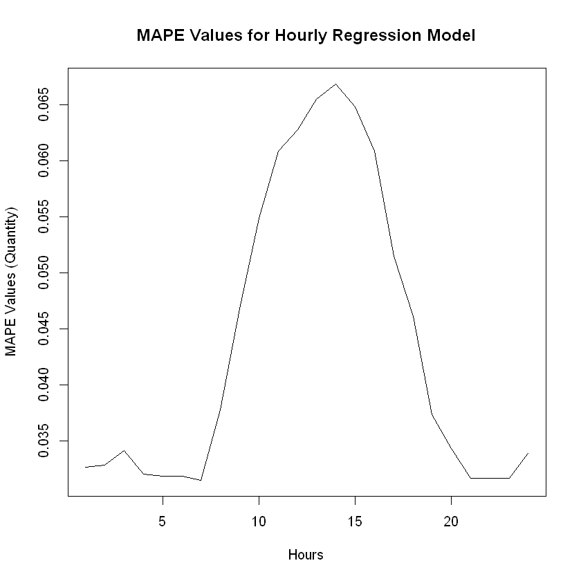

```r
plot(mape_result_c,type="l",ylab="MAPE Values (Quantity)",xlab="Hours",main="MAPE Values for Hourly Regression Model")
```

```r
C_all_val=c(MAPE0c_reg_values,MAPE1c_reg_values,MAPE2c_reg_values,MAPE3c_reg_values,MAPE4c_reg_values,MAPE5c_reg_values,
           MAPE6c_reg_values,MAPE7c_reg_values,MAPE8c_reg_values,MAPE9c_reg_values,MAPE10c_reg_values,MAPE11c_reg_values,
           MAPE12c_reg_values,MAPE13c_reg_values,MAPE14c_reg_values,MAPE15c_reg_values,MAPE16c_reg_values,MAPE17c_reg_values,
           MAPE18c_reg_values,MAPE19c_reg_values,MAPE20c_reg_values,MAPE21c_reg_values,MAPE22c_reg_values,MAPE23c_reg_values)
```

## General Summary Statistic for Hourly Model

```r
summary(C_all_val)
```

```
     Min.   1st Qu.    Median      Mean   3rd Qu.      Max.
0.0004843 0.0216021 0.0372756 0.0435845 0.0590627 0.1656688
```

# PART D

```r
cont=copy(dt)
```

## Lag Creator Function

```r
lag_creator<-function(DT, names){
    hours=c(0:23)
    for (which_hour in hours){
        new_col<-paste0(names,which_hour)
        which_hour=which_hour+1
        DT[,(new_col):=shift(DT[,2],type="lag",n=which_hour)]

        }
    return(DT[])
}
```

## Feature Matrix Creator

```r
feature_mat<-function(DT,names){
    feat_mat=data.table(date=seq.POSIXt(from = as.POSIXct("2016-01-01"),to = as.POSIXct("2020-12-01"),by="day"))
    hours=c(0:23)
    for (which_hour in hours){
    new_col<-paste0(names,which_hour)
    feat_mat[,(new_col):=0]
    }
    for(whic_date in seq.POSIXt(from = as.POSIXct("2016-01-01"),to = as.POSIXct("2020-12-01"),by="day")){
        current_DT=filter(DT,date==as.POSIXct(whic_date, origin = "1970-01-01"))
        print(current_DT)
        for(which_hour in hours){
            feat_mat[date==as.POSIXct(whic_date, origin = "1970-01-01"),
                     feat_mat[,which_hour+1]:=current_DT[hour==which_hour,consumption]]
        }
    }
    return(feat_mat[])
}
```

## Column Name Creator

```r
col_name<-function(DT, names){
    hours=c(0:23)
    for (which_hour in hours){
        new_col<-paste0(names,which_hour)
        setnames(DT,old=as.character(which_hour),new=as.character(new_col))
        }
}
```

```r
data_wide <- spread(cont, hour, consumption)
lag_2=copy(data_wide[,date:=date+2])
col_name(lag_2,"Lag_day2_hour_")
#lag_2
```

```r
data_wide <- spread(cont, hour, consumption)
lag_7=copy(data_wide[,date:=date+7])
col_name(lag_7,"Lag_day7_hour_")
#lag_7
```

```r
dt_with_lag2=merge(cont,lag_2,by.x="date",by.y="date",all.x=TRUE)
```

```r
full_dt=merge(dt_with_lag2,lag_7,by.x="date",by.y="date",all.x=TRUE)
```

## Final Dataset for Part D

```r
full_dt %>% relocate(consumption, .after = last_col())
#full_dt
```

| date | hour | Lag_day2_hour_0 | Lag_day2_hour_1 | Lag_day2_hour_2 | Lag_day2_hour_3 | Lag_day2_hour_4 | Lag_day2_hour_5 | Lag_day2_hour_6 | Lag_day2_hour_7 | ... | Lag_day7_hour_15 | Lag_day7_hour_16 | Lag_day7_hour_17 | Lag_day7_hour_18 | Lag_day7_hour_19 | Lag_day7_hour_20 | Lag_day7_hour_21 | Lag_day7_hour_22 | Lag_day7_hour_23 | consumption |
| --- | --- | --- | --- | --- | --- | --- | --- | --- | --- | --- | --- | --- | --- | --- | --- | --- | --- | --- | --- | --- |
| 2016-01-01 | 0 | NA | NA | NA | NA | NA | NA | NA | NA | ... | NA | NA | NA | NA | NA | NA | NA | NA | NA | 26277.24 |
| 2016-01-01 | 1 | NA | NA | NA | NA | NA | NA | NA | NA | ... | NA | NA | NA | NA | NA | NA | NA | NA | NA | 24991.82 |
| 2016-01-01 | 2 | NA | NA | NA | NA | NA | NA | NA | NA | ... | NA | NA | NA | NA | NA | NA | NA | NA | NA | 23532.61 |
| 2016-01-01 | 3 | NA | NA | NA | NA | NA | NA | NA | NA | ... | NA | NA | NA | NA | NA | NA | NA | NA | NA | 22464.78 |
| 2016-01-01 | 4 | NA | NA | NA | NA | NA | NA | NA | NA | ... | NA | NA | NA | NA | NA | NA | NA | NA | NA | 22002.91 |
| 2016-01-01 | 5 | NA | NA | NA | NA | NA | NA | NA | NA | ... | NA | NA | NA | NA | NA | NA | NA | NA | NA | 21957.08 |
| 2016-01-01 | 6 | NA | NA | NA | NA | NA | NA | NA | NA | ... | NA | NA | NA | NA | NA | NA | NA | NA | NA | 22203.54 |
| 2016-01-01 | 7 | NA | NA | NA | NA | NA | NA | NA | NA | ... | NA | NA | NA | NA | NA | NA | NA | NA | NA | 21844.16 |
| 2016-01-01 | 8 | NA | NA | NA | NA | NA | NA | NA | NA | ... | NA | NA | NA | NA | NA | NA | NA | NA | NA | 23094.73 |
| 2016-01-01 | 9 | NA | NA | NA | NA | NA | NA | NA | NA | ... | NA | NA | NA | NA | NA | NA | NA | NA | NA | 25202.27 |
| 2016-01-01 | 10 | NA | NA | NA | NA | NA | NA | NA | NA | ... | NA | NA | NA | NA | NA | NA | NA | NA | NA | 27224.96 |
| 2016-01-01 | 11 | NA | NA | NA | NA | NA | NA | NA | NA | ... | NA | NA | NA | NA | NA | NA | NA | NA | NA | 28908.04 |
| 2016-01-01 | 12 | NA | NA | NA | NA | NA | NA | NA | NA | ... | NA | NA | NA | NA | NA | NA | NA | NA | NA | 28789.25 |
| 2016-01-01 | 13 | NA | NA | NA | NA | NA | NA | NA | NA | ... | NA | NA | NA | NA | NA | NA | NA | NA | NA | 29367.70 |
| 2016-01-01 | 14 | NA | NA | NA | NA | NA | NA | NA | NA | ... | NA | NA | NA | NA | NA | NA | NA | NA | NA | 29548.32 |
| 2016-01-01 | 15 | NA | NA | NA | NA | NA | NA | NA | NA | ... | NA | NA | NA | NA | NA | NA | NA | NA | NA | 29390.89 |
| 2016-01-01 | 16 | NA | NA | NA | NA | NA | NA | NA | NA | ... | NA | NA | NA | NA | NA | NA | NA | NA | NA | 30734.97 |
| 2016-01-01 | 17 | NA | NA | NA | NA | NA | NA | NA | NA | ... | NA | NA | NA | NA | NA | NA | NA | NA | NA | 32048.02 |
| 2016-01-01 | 18 | NA | NA | NA | NA | NA | NA | NA | NA | ... | NA | NA | NA | NA | NA | NA | NA | NA | NA | 31438.11 |
| 2016-01-01 | 19 | NA | NA | NA | NA | NA | NA | NA | NA | ... | NA | NA | NA | NA | NA | NA | NA | NA | NA | 30728.47 |
| 2016-01-01 | 20 | NA | NA | NA | NA | NA | NA | NA | NA | ... | NA | NA | NA | NA | NA | NA | NA | NA | NA | 30166.14 |
| 2016-01-01 | 21 | NA | NA | NA | NA | NA | NA | NA | NA | ... | NA | NA | NA | NA | NA | NA | NA | NA | NA | 29461.28 |
| 2016-01-01 | 22 | NA | NA | NA | NA | NA | NA | NA | NA | ... | NA | NA | NA | NA | NA | NA | NA | NA | NA | 29242.83 |
| 2016-01-01 | 23 | NA | NA | NA | NA | NA | NA | NA | NA | ... | NA | NA | NA | NA | NA | NA | NA | NA | NA | 28069.09 |
| 2016-01-02 | 0 | NA | NA | NA | NA | NA | NA | NA | NA | ... | NA | NA | NA | NA | NA | NA | NA | NA | NA | 26224.60 |
| 2016-01-02 | 1 | NA | NA | NA | NA | NA | NA | NA | NA | ... | NA | NA | NA | NA | NA | NA | NA | NA | NA | 24708.58 |
| 2016-01-02 | 2 | NA | NA | NA | NA | NA | NA | NA | NA | ... | NA | NA | NA | NA | NA | NA | NA | NA | NA | 23771.58 |
| 2016-01-02 | 3 | NA | NA | NA | NA | NA | NA | NA | NA | ... | NA | NA | NA | NA | NA | NA | NA | NA | NA | 22921.29 |
| 2016-01-02 | 4 | NA | NA | NA | NA | NA | NA | NA | NA | ... | NA | NA | NA | NA | NA | NA | NA | NA | NA | 22870.89 |
| 2016-01-02 | 5 | NA | NA | NA | NA | NA | NA | NA | NA | ... | NA | NA | NA | NA | NA | NA | NA | NA | NA | 23325.63 |
| ... | ... | ... | ... | ... | ... | ... | ... | ... | ... |  | ... | ... | ... | ... | ... | ... | ... | ... | ... | ... |
| 2020-11-30 | 18 | 33935.56 | 31919.44 | 30439.27 | 30020.41 | 29825.63 | 29984.86 | 30444.97 | 31159.67 | ... | 37586.08 | 39435.91 | 41569.99 | 41710.94 | 40297.34 | 38951.67 | 37856.67 | 36983.95 | 35594.03 | 42245.38 |
| 2020-11-30 | 19 | 33935.56 | 31919.44 | 30439.27 | 30020.41 | 29825.63 | 29984.86 | 30444.97 | 31159.67 | ... | 37586.08 | 39435.91 | 41569.99 | 41710.94 | 40297.34 | 38951.67 | 37856.67 | 36983.95 | 35594.03 | 40750.73 |
| 2020-11-30 | 20 | 33935.56 | 31919.44 | 30439.27 | 30020.41 | 29825.63 | 29984.86 | 30444.97 | 31159.67 | ... | 37586.08 | 39435.91 | 41569.99 | 41710.94 | 40297.34 | 38951.67 | 37856.67 | 36983.95 | 35594.03 | 39294.57 |
| 2020-11-30 | 21 | 33935.56 | 31919.44 | 30439.27 | 30020.41 | 29825.63 | 29984.86 | 30444.97 | 31159.67 | ... | 37586.08 | 39435.91 | 41569.99 | 41710.94 | 40297.34 | 38951.67 | 37856.67 | 36983.95 | 35594.03 | 38212.74 |
| 2020-11-30 | 22 | 33935.56 | 31919.44 | 30439.27 | 30020.41 | 29825.63 | 29984.86 | 30444.97 | 31159.67 | ... | 37586.08 | 39435.91 | 41569.99 | 41710.94 | 40297.34 | 38951.67 | 37856.67 | 36983.95 | 35594.03 | 37225.65 |
| 2020-11-30 | 23 | 33935.56 | 31919.44 | 30439.27 | 30020.41 | 29825.63 | 29984.86 | 30444.97 | 31159.67 | ... | 37586.08 | 39435.91 | 41569.99 | 41710.94 | 40297.34 | 38951.67 | 37856.67 | 36983.95 | 35594.03 | 35775.04 |
| 2020-12-01 | 0 | 32332.68 | 30410.13 | 29119.33 | 28484.61 | 28150.14 | 28065.44 | 28189.16 | 27883.71 | ... | 38656.92 | 40396.69 | 42486.34 | 42255.24 | 40895.17 | 39240.65 | 38366.41 | 37446.73 | 36186.83 | 33842.13 |
| 2020-12-01 | 1 | 32332.68 | 30410.13 | 29119.33 | 28484.61 | 28150.14 | 28065.44 | 28189.16 | 27883.71 | ... | 38656.92 | 40396.69 | 42486.34 | 42255.24 | 40895.17 | 39240.65 | 38366.41 | 37446.73 | 36186.83 | 32013.00 |
| 2020-12-01 | 2 | 32332.68 | 30410.13 | 29119.33 | 28484.61 | 28150.14 | 28065.44 | 28189.16 | 27883.71 | ... | 38656.92 | 40396.69 | 42486.34 | 42255.24 | 40895.17 | 39240.65 | 38366.41 | 37446.73 | 36186.83 | 30884.17 |
| 2020-12-01 | 3 | 32332.68 | 30410.13 | 29119.33 | 28484.61 | 28150.14 | 28065.44 | 28189.16 | 27883.71 | ... | 38656.92 | 40396.69 | 42486.34 | 42255.24 | 40895.17 | 39240.65 | 38366.41 | 37446.73 | 36186.83 | 30082.68 |
| 2020-12-01 | 4 | 32332.68 | 30410.13 | 29119.33 | 28484.61 | 28150.14 | 28065.44 | 28189.16 | 27883.71 | ... | 38656.92 | 40396.69 | 42486.34 | 42255.24 | 40895.17 | 39240.65 | 38366.41 | 37446.73 | 36186.83 | 29844.18 |
| 2020-12-01 | 5 | 32332.68 | 30410.13 | 29119.33 | 28484.61 | 28150.14 | 28065.44 | 28189.16 | 27883.71 | ... | 38656.92 | 40396.69 | 42486.34 | 42255.24 | 40895.17 | 39240.65 | 38366.41 | 37446.73 | 36186.83 | 30100.53 |
| 2020-12-01 | 6 | 32332.68 | 30410.13 | 29119.33 | 28484.61 | 28150.14 | 28065.44 | 28189.16 | 27883.71 | ... | 38656.92 | 40396.69 | 42486.34 | 42255.24 | 40895.17 | 39240.65 | 38366.41 | 37446.73 | 36186.83 | 30743.44 |
| 2020-12-01 | 7 | 32332.68 | 30410.13 | 29119.33 | 28484.61 | 28150.14 | 28065.44 | 28189.16 | 27883.71 | ... | 38656.92 | 40396.69 | 42486.34 | 42255.24 | 40895.17 | 39240.65 | 38366.41 | 37446.73 | 36186.83 | 32279.80 |
| 2020-12-01 | 8 | 32332.68 | 30410.13 | 29119.33 | 28484.61 | 28150.14 | 28065.44 | 28189.16 | 27883.71 | ... | 38656.92 | 40396.69 | 42486.34 | 42255.24 | 40895.17 | 39240.65 | 38366.41 | 37446.73 | 36186.83 | 36657.05 |
| 2020-12-01 | 9 | 32332.68 | 30410.13 | 29119.33 | 28484.61 | 28150.14 | 28065.44 | 28189.16 | 27883.71 | ... | 38656.92 | 40396.69 | 42486.34 | 42255.24 | 40895.17 | 39240.65 | 38366.41 | 37446.73 | 36186.83 | 39815.64 |
| 2020-12-01 | 10 | 32332.68 | 30410.13 | 29119.33 | 28484.61 | 28150.14 | 28065.44 | 28189.16 | 27883.71 | ... | 38656.92 | 40396.69 | 42486.34 | 42255.24 | 40895.17 | 39240.65 | 38366.41 | 37446.73 | 36186.83 | 40846.18 |
| 2020-12-01 | 11 | 32332.68 | 30410.13 | 29119.33 | 28484.61 | 28150.14 | 28065.44 | 28189.16 | 27883.71 | ... | 38656.92 | 40396.69 | 42486.34 | 42255.24 | 40895.17 | 39240.65 | 38366.41 | 37446.73 | 36186.83 | 41320.19 |
| 2020-12-01 | 12 | 32332.68 | 30410.13 | 29119.33 | 28484.61 | 28150.14 | 28065.44 | 28189.16 | 27883.71 | ... | 38656.92 | 40396.69 | 42486.34 | 42255.24 | 40895.17 | 39240.65 | 38366.41 | 37446.73 | 36186.83 | 40054.73 |
| 2020-12-01 | 13 | 32332.68 | 30410.13 | 29119.33 | 28484.61 | 28150.14 | 28065.44 | 28189.16 | 27883.71 | ... | 38656.92 | 40396.69 | 42486.34 | 42255.24 | 40895.17 | 39240.65 | 38366.41 | 37446.73 | 36186.83 | 40874.30 |
| 2020-12-01 | 14 | 32332.68 | 30410.13 | 29119.33 | 28484.61 | 28150.14 | 28065.44 | 28189.16 | 27883.71 | ... | 38656.92 | 40396.69 | 42486.34 | 42255.24 | 40895.17 | 39240.65 | 38366.41 | 37446.73 | 36186.83 | 41812.33 |
| 2020-12-01 | 15 | 32332.68 | 30410.13 | 29119.33 | 28484.61 | 28150.14 | 28065.44 | 28189.16 | 27883.71 | ... | 38656.92 | 40396.69 | 42486.34 | 42255.24 | 40895.17 | 39240.65 | 38366.41 | 37446.73 | 36186.83 | 41722.82 |
| 2020-12-01 | 16 | 32332.68 | 30410.13 | 29119.33 | 28484.61 | 28150.14 | 28065.44 | 28189.16 | 27883.71 | ... | 38656.92 | 40396.69 | 42486.34 | 42255.24 | 40895.17 | 39240.65 | 38366.41 | 37446.73 | 36186.83 | 42341.25 |
| 2020-12-01 | 17 | 32332.68 | 30410.13 | 29119.33 | 28484.61 | 28150.14 | 28065.44 | 28189.16 | 27883.71 | ... | 38656.92 | 40396.69 | 42486.34 | 42255.24 | 40895.17 | 39240.65 | 38366.41 | 37446.73 | 36186.83 | 43320.35 |
| 2020-12-01 | 18 | 32332.68 | 30410.13 | 29119.33 | 28484.61 | 28150.14 | 28065.44 | 28189.16 | 27883.71 | ... | 38656.92 | 40396.69 | 42486.34 | 42255.24 | 40895.17 | 39240.65 | 38366.41 | 37446.73 | 36186.83 | 42292.06 |
| 2020-12-01 | 19 | 32332.68 | 30410.13 | 29119.33 | 28484.61 | 28150.14 | 28065.44 | 28189.16 | 27883.71 | ... | 38656.92 | 40396.69 | 42486.34 | 42255.24 | 40895.17 | 39240.65 | 38366.41 | 37446.73 | 36186.83 | 40720.16 |
| 2020-12-01 | 20 | 32332.68 | 30410.13 | 29119.33 | 28484.61 | 28150.14 | 28065.44 | 28189.16 | 27883.71 | ... | 38656.92 | 40396.69 | 42486.34 | 42255.24 | 40895.17 | 39240.65 | 38366.41 | 37446.73 | 36186.83 | 39195.74 |
| 2020-12-01 | 21 | 32332.68 | 30410.13 | 29119.33 | 28484.61 | 28150.14 | 28065.44 | 28189.16 | 27883.71 | ... | 38656.92 | 40396.69 | 42486.34 | 42255.24 | 40895.17 | 39240.65 | 38366.41 | 37446.73 | 36186.83 | 38310.79 |
| 2020-12-01 | 22 | 32332.68 | 30410.13 | 29119.33 | 28484.61 | 28150.14 | 28065.44 | 28189.16 | 27883.71 | ... | 38656.92 | 40396.69 | 42486.34 | 42255.24 | 40895.17 | 39240.65 | 38366.41 | 37446.73 | 36186.83 | 37173.97 |
| 2020-12-01 | 23 | 32332.68 | 30410.13 | 29119.33 | 28484.61 | 28150.14 | 28065.44 | 28189.16 | 27883.71 | ... | 38656.92 | 40396.69 | 42486.34 | 42255.24 | 40895.17 | 39240.65 | 38366.41 | 37446.73 | 36186.83 | 35725.46 |

```r
train_d=filter(full_dt,date<="2020-10-31")
#train
```

```r
test_d=filter(full_dt,date>"2020-10-31")
#test
```

```r
names_train<-paste0("train_d",0:23)
names_test<-paste0("test_d",0:23)
```

```r
train_split <- split(train_d, train_d$hour)
new_names_train <- names_train
for (i in 1:length(train_split)) {
  assign(new_names_train[i], train_split[[i]])
}
```

```r
test_split <- split(test_d, test_d$hour)
new_names_test <- names_test
for (i in 1:length(test_split)) {
  assign(new_names_test[i], test_split[[i]])
}
```

## Model Training

```r
#print(cvfit$name)
#print(cvfit$glmnet.fit)
#print(cvfit$lambda.1se)
#print(cvfit$lambda.min)
#plot(cvfit)
#coef(cvfit,s="lambda.min")
#coef(cvfit,s="lambda.1se")
```

```r
mape_result_d=rep(0,24)
```

```r
set.seed(1)
```

```r
train_mat0=as.matrix(train_d0[complete.cases(train_d0),-c('date',"hour","consumption"),with=F])
train_mat1=as.matrix(train_d1[complete.cases(train_d1),-c('date',"hour","consumption"),with=F])
train_mat2=as.matrix(train_d2[complete.cases(train_d2),-c('date',"hour","consumption"),with=F])
train_mat3=as.matrix(train_d3[complete.cases(train_d3),-c('date',"hour","consumption"),with=F])
train_mat4=as.matrix(train_d4[complete.cases(train_d4),-c('date',"hour","consumption"),with=F])
train_mat5=as.matrix(train_d5[complete.cases(train_d5),-c('date',"hour","consumption"),with=F])
train_mat6=as.matrix(train_d6[complete.cases(train_d6),-c('date',"hour","consumption"),with=F])
train_mat7=as.matrix(train_d7[complete.cases(train_d7),-c('date',"hour","consumption"),with=F])
train_mat8=as.matrix(train_d8[complete.cases(train_d8),-c('date',"hour","consumption"),with=F])
train_mat9=as.matrix(train_d9[complete.cases(train_d9),-c('date',"hour","consumption"),with=F])
train_mat10=as.matrix(train_d10[complete.cases(train_d10),-c('date',"hour","consumption"),with=F])
train_mat11=as.matrix(train_d11[complete.cases(train_d11),-c('date',"hour","consumption"),with=F])
train_mat12=as.matrix(train_d12[complete.cases(train_d12),-c('date',"hour","consumption"),with=F])
train_mat13=as.matrix(train_d13[complete.cases(train_d13),-c('date',"hour","consumption"),with=F])
train_mat14=as.matrix(train_d14[complete.cases(train_d14),-c('date',"hour","consumption"),with=F])
train_mat15=as.matrix(train_d15[complete.cases(train_d15),-c('date',"hour","consumption"),with=F])
train_mat16=as.matrix(train_d16[complete.cases(train_d16),-c('date',"hour","consumption"),with=F])
train_mat17=as.matrix(train_d17[complete.cases(train_d17),-c('date',"hour","consumption"),with=F])
train_mat18=as.matrix(train_d18[complete.cases(train_d18),-c('date',"hour","consumption"),with=F])
train_mat19=as.matrix(train_d19[complete.cases(train_d19),-c('date',"hour","consumption"),with=F])
train_mat20=as.matrix(train_d20[complete.cases(train_d20),-c('date',"hour","consumption"),with=F])
train_mat21=as.matrix(train_d21[complete.cases(train_d21),-c('date',"hour","consumption"),with=F])
train_mat22=as.matrix(train_d22[complete.cases(train_d22),-c('date',"hour","consumption"),with=F])
train_mat23=as.matrix(train_d23[complete.cases(train_d23),-c('date',"hour","consumption"),with=F])
```

```r
result_vec0=as.vector(t(train_d0[complete.cases(train_d0),"consumption"]))
result_vec1=as.vector(t(train_d1[complete.cases(train_d1),"consumption"]))
result_vec2=as.vector(t(train_d2[complete.cases(train_d2),"consumption"]))
result_vec3=as.vector(t(train_d3[complete.cases(train_d3),"consumption"]))
result_vec4=as.vector(t(train_d4[complete.cases(train_d4),"consumption"]))
result_vec5=as.vector(t(train_d5[complete.cases(train_d5),"consumption"]))
result_vec6=as.vector(t(train_d6[complete.cases(train_d6),"consumption"]))
result_vec7=as.vector(t(train_d7[complete.cases(train_d7),"consumption"]))
result_vec8=as.vector(t(train_d8[complete.cases(train_d8),"consumption"]))
result_vec9=as.vector(t(train_d9[complete.cases(train_d9),"consumption"]))
result_vec10=as.vector(t(train_d10[complete.cases(train_d10),"consumption"]))
result_vec11=as.vector(t(train_d11[complete.cases(train_d11),"consumption"]))
result_vec12=as.vector(t(train_d12[complete.cases(train_d12),"consumption"]))
result_vec13=as.vector(t(train_d13[complete.cases(train_d13),"consumption"]))
result_vec14=as.vector(t(train_d14[complete.cases(train_d14),"consumption"]))
result_vec15=as.vector(t(train_d15[complete.cases(train_d15),"consumption"]))
result_vec16=as.vector(t(train_d16[complete.cases(train_d16),"consumption"]))
result_vec17=as.vector(t(train_d17[complete.cases(train_d17),"consumption"]))
result_vec18=as.vector(t(train_d18[complete.cases(train_d18),"consumption"]))
result_vec19=as.vector(t(train_d19[complete.cases(train_d19),"consumption"]))
result_vec20=as.vector(t(train_d20[complete.cases(train_d20),"consumption"]))
result_vec21=as.vector(t(train_d21[complete.cases(train_d21),"consumption"]))
result_vec22=as.vector(t(train_d22[complete.cases(train_d22),"consumption"]))
result_vec23=as.vector(t(train_d23[complete.cases(train_d23),"consumption"]))
```

## Important Note: Type of Measure determined as mae

```r
cvfit0=cv.glmnet(train_mat0,result_vec0,family='gaussian',nfolds = 10,type.measure="mae")
cvfit1=cv.glmnet(train_mat1,result_vec1,family='gaussian',nfolds = 10,type.measure="mae")
cvfit2=cv.glmnet(train_mat2,result_vec2,family='gaussian',nfolds = 10,type.measure="mae")
cvfit3=cv.glmnet(train_mat3,result_vec3,family='gaussian',nfolds = 10,type.measure="mae")
cvfit4=cv.glmnet(train_mat4,result_vec4,family='gaussian',nfolds = 10,type.measure="mae")
cvfit5=cv.glmnet(train_mat5,result_vec5,family='gaussian',nfolds = 10,type.measure="mae")
cvfit6=cv.glmnet(train_mat6,result_vec6,family='gaussian',nfolds = 10,type.measure="mae")
cvfit7=cv.glmnet(train_mat7,result_vec7,family='gaussian',nfolds = 10,type.measure="mae")
cvfit8=cv.glmnet(train_mat8,result_vec8,family='gaussian',nfolds = 10,type.measure="mae")
cvfit9=cv.glmnet(train_mat9,result_vec9,family='gaussian',nfolds = 10,type.measure="mae")
cvfit10=cv.glmnet(train_mat10,result_vec10,family='gaussian',nfolds = 10,type.measure="mae")
cvfit11=cv.glmnet(train_mat11,result_vec11,family='gaussian',nfolds = 10,type.measure="mae")
cvfit12=cv.glmnet(train_mat12,result_vec12,family='gaussian',nfolds = 10,type.measure="mae")
cvfit13=cv.glmnet(train_mat13,result_vec13,family='gaussian',nfolds = 10,type.measure="mae")
cvfit14=cv.glmnet(train_mat14,result_vec14,family='gaussian',nfolds = 10,type.measure="mae")
cvfit15=cv.glmnet(train_mat15,result_vec15,family='gaussian',nfolds = 10,type.measure="mae")
cvfit16=cv.glmnet(train_mat16,result_vec16,family='gaussian',nfolds = 10,type.measure="mae")
cvfit17=cv.glmnet(train_mat17,result_vec17,family='gaussian',nfolds = 10,type.measure="mae")
cvfit18=cv.glmnet(train_mat18,result_vec18,family='gaussian',nfolds = 10,type.measure="mae")
cvfit19=cv.glmnet(train_mat19,result_vec19,family='gaussian',nfolds = 10,type.measure="mae")
cvfit20=cv.glmnet(train_mat20,result_vec20,family='gaussian',nfolds = 10,type.measure="mae")
cvfit21=cv.glmnet(train_mat21,result_vec21,family='gaussian',nfolds = 10,type.measure="mae")
cvfit22=cv.glmnet(train_mat22,result_vec22,family='gaussian',nfolds = 10,type.measure="mae")
cvfit23=cv.glmnet(train_mat23,result_vec23,family='gaussian',nfolds = 10,type.measure="mae")
```

```
[1] "Hour 0"
[1] "Min value for Lambda= 2.69421511209774"
[1] "1se value for Lambda= 9.02993850173514"
49 x 1 sparse Matrix of class "dgCMatrix"
                             1
(Intercept)      1368.86152133
Lag_day2_hour_0    -0.22440602
Lag_day2_hour_1    -0.06112433
Lag_day2_hour_2     .
Lag_day2_hour_3     .
Lag_day2_hour_4     0.03505511
Lag_day2_hour_5     .
Lag_day2_hour_6     .
Lag_day2_hour_7     0.39057738
Lag_day2_hour_8     .
Lag_day2_hour_9    -0.58620664
Lag_day2_hour_10   -0.14370971
Lag_day2_hour_11   -0.10384129
Lag_day2_hour_12    .
Lag_day2_hour_13    0.32470760
Lag_day2_hour_14    .
Lag_day2_hour_15    .
Lag_day2_hour_16    0.01964243
Lag_day2_hour_17    .
Lag_day2_hour_18    .
Lag_day2_hour_19    .
Lag_day2_hour_20   -0.01284033
Lag_day2_hour_21    .
Lag_day2_hour_22    0.27314067
Lag_day2_hour_23    1.04198291
Lag_day7_hour_0     0.08044803
Lag_day7_hour_1     .
Lag_day7_hour_2     .
Lag_day7_hour_3     .
Lag_day7_hour_4     .
Lag_day7_hour_5     .
Lag_day7_hour_6     0.12052488
Lag_day7_hour_7     0.18682570
Lag_day7_hour_8     .
Lag_day7_hour_9     .
Lag_day7_hour_10    .
Lag_day7_hour_11    0.04084598
Lag_day7_hour_12    0.02183069
Lag_day7_hour_13    .
Lag_day7_hour_14    0.04672106
Lag_day7_hour_15    .
Lag_day7_hour_16    .
Lag_day7_hour_17    .
Lag_day7_hour_18   -0.01618301
Lag_day7_hour_19   -0.19516967
Lag_day7_hour_20   -0.20979365
Lag_day7_hour_21    .
Lag_day7_hour_22    .
Lag_day7_hour_23    .
[1] "Plot for 0'th hour's Cross Validation"
```

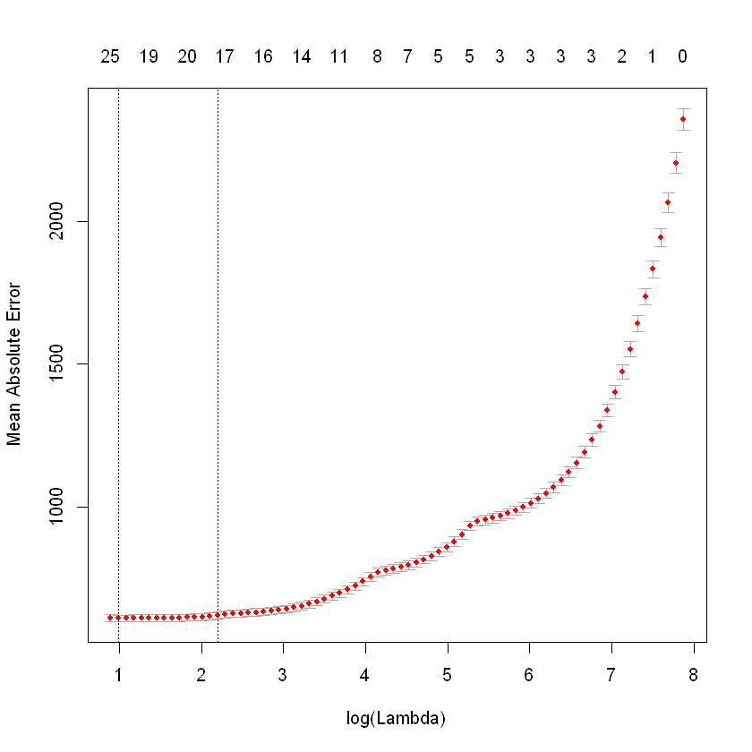

```
[1] "Hour 1"
[1] "Min value for Lambda= 1.78681328807348"
[1] "1se value for Lambda= 5.45666959736646"
49 x 1 sparse Matrix of class "dgCMatrix"
                             1
(Intercept)       1.370259e+03
Lag_day2_hour_0  -4.482659e-01
Lag_day2_hour_1   .
Lag_day2_hour_2   .
Lag_day2_hour_3   4.370851e-05
Lag_day2_hour_4   2.703915e-01
Lag_day2_hour_5   .
Lag_day2_hour_6   .
Lag_day2_hour_7   3.545145e-01
Lag_day2_hour_8   .
Lag_day2_hour_9  -5.945923e-01
Lag_day2_hour_10  .
Lag_day2_hour_11 -2.856690e-01
Lag_day2_hour_12  9.021815e-03
Lag_day2_hour_13  3.234469e-01
Lag_day2_hour_14  .
Lag_day2_hour_15  .
Lag_day2_hour_16  9.255235e-02
Lag_day2_hour_17  .
Lag_day2_hour_18  .
Lag_day2_hour_19  .
Lag_day2_hour_20 -1.436557e-01
Lag_day2_hour_21  1.009379e-03
Lag_day2_hour_22  3.252758e-01
Lag_day2_hour_23  1.043699e+00
Lag_day7_hour_0   .
Lag_day7_hour_1   6.851044e-02
Lag_day7_hour_2   .
Lag_day7_hour_3   .
Lag_day7_hour_4   .
Lag_day7_hour_5   .
Lag_day7_hour_6   7.413331e-02
Lag_day7_hour_7   2.387580e-01
Lag_day7_hour_8   .
Lag_day7_hour_9   .
Lag_day7_hour_10  .
Lag_day7_hour_11  .
Lag_day7_hour_12  .
Lag_day7_hour_13  .
Lag_day7_hour_14  1.002548e-01
Lag_day7_hour_15  1.536900e-02
Lag_day7_hour_16  .
Lag_day7_hour_17 -9.023844e-03
Lag_day7_hour_18 -9.111822e-02
Lag_day7_hour_19 -8.492483e-02
Lag_day7_hour_20 -2.356758e-01
Lag_day7_hour_21  .
Lag_day7_hour_22 -5.271443e-03
Lag_day7_hour_23  .
[1] "Plot for 1'th hour's Cross Validation"
```

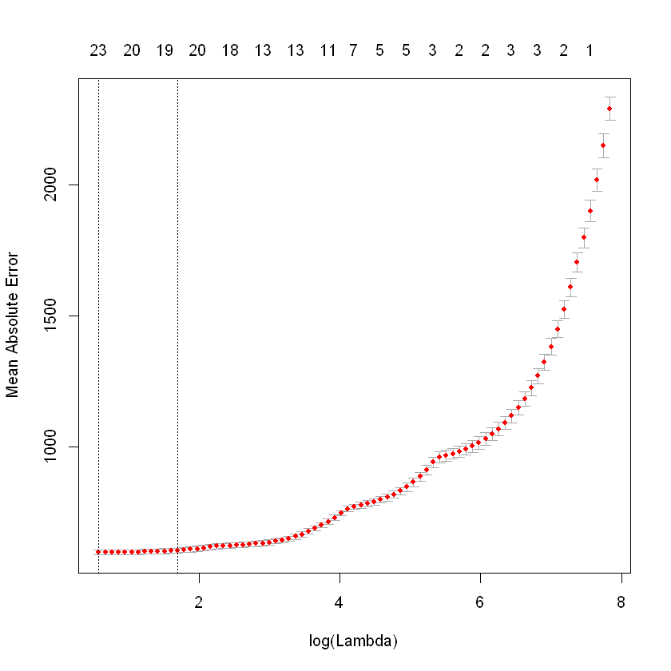

```
[1] "Hour 2"
[1] "Min value for Lambda= 2.04912564696771"
[1] "1se value for Lambda= 9.96408159402096"
49 x 1 sparse Matrix of class "dgCMatrix"
                             1
(Intercept)       1.800329e+03
Lag_day2_hour_0  -6.842063e-01
Lag_day2_hour_1   .
Lag_day2_hour_2   2.385729e-05
Lag_day2_hour_3   2.826531e-01
Lag_day2_hour_4   3.037186e-01
Lag_day2_hour_5   .
Lag_day2_hour_6   .
Lag_day2_hour_7   2.713106e-01
Lag_day2_hour_8   .
Lag_day2_hour_9  -4.730271e-01
Lag_day2_hour_10 -1.786534e-01
Lag_day2_hour_11 -2.603415e-01
Lag_day2_hour_12  1.948278e-01
Lag_day2_hour_13  1.818766e-01
Lag_day2_hour_14  .
Lag_day2_hour_15  5.520478e-05
Lag_day2_hour_16  1.124358e-01
Lag_day2_hour_17  .
Lag_day2_hour_18 -2.232604e-02
Lag_day2_hour_19  .
Lag_day2_hour_20 -1.540590e-01
Lag_day2_hour_21  1.136349e-01
Lag_day2_hour_22  2.737914e-01
Lag_day2_hour_23  9.844208e-01
Lag_day7_hour_0  -2.512746e-02
Lag_day7_hour_1   .
Lag_day7_hour_2   .
Lag_day7_hour_3   5.426740e-02
Lag_day7_hour_4   .
Lag_day7_hour_5   .
Lag_day7_hour_6   1.043437e-01
Lag_day7_hour_7   2.269694e-01
Lag_day7_hour_8   3.772277e-02
Lag_day7_hour_9   .
Lag_day7_hour_10  .
Lag_day7_hour_11  .
Lag_day7_hour_12  .
Lag_day7_hour_13  .
Lag_day7_hour_14  5.482259e-02
Lag_day7_hour_15  6.031312e-02
Lag_day7_hour_16  1.399185e-03
Lag_day7_hour_17  .
Lag_day7_hour_18 -8.289962e-02
Lag_day7_hour_19 -1.010319e-01
Lag_day7_hour_20 -2.303430e-01
Lag_day7_hour_21  .
Lag_day7_hour_22 -4.223077e-02
Lag_day7_hour_23  .
[1] "Plot for 2'th hour's Cross Validation"
```

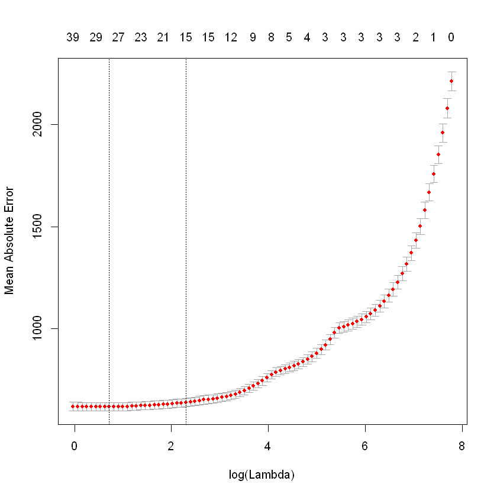

```
[1] "Hour 3"
[1] "Min value for Lambda= 1.01908010939191"
[1] "1se value for Lambda= 7.18940869746412"
49 x 1 sparse Matrix of class "dgCMatrix"
                             1
(Intercept)       1.924504e+03
Lag_day2_hour_0  -6.521702e-01
Lag_day2_hour_1  -2.539439e-01
Lag_day2_hour_2   .
Lag_day2_hour_3   1.692159e-01
Lag_day2_hour_4   6.613499e-01
Lag_day2_hour_5   .
Lag_day2_hour_6   .
Lag_day2_hour_7   2.768708e-01
Lag_day2_hour_8   .
Lag_day2_hour_9  -5.430618e-01
Lag_day2_hour_10 -2.153011e-02
Lag_day2_hour_11 -3.300013e-01
Lag_day2_hour_12  4.323491e-02
Lag_day2_hour_13  3.571806e-01
Lag_day2_hour_14 -5.462359e-02
Lag_day2_hour_15  5.534575e-03
Lag_day2_hour_16  1.004755e-01
Lag_day2_hour_17  .
Lag_day2_hour_18  .
Lag_day2_hour_19  2.582739e-02
Lag_day2_hour_20 -2.101376e-01
Lag_day2_hour_21  7.770036e-02
Lag_day2_hour_22  2.900126e-01
Lag_day2_hour_23  9.913948e-01
Lag_day7_hour_0   .
Lag_day7_hour_1   1.055840e-02
Lag_day7_hour_2   .
Lag_day7_hour_3   .
Lag_day7_hour_4   .
Lag_day7_hour_5   .
Lag_day7_hour_6   2.414492e-02
Lag_day7_hour_7   3.184974e-01
Lag_day7_hour_8   .
Lag_day7_hour_9  -2.858867e-03
Lag_day7_hour_10  .
Lag_day7_hour_11  .
Lag_day7_hour_12 -6.515155e-03
Lag_day7_hour_13  2.827184e-02
Lag_day7_hour_14  3.382778e-02
Lag_day7_hour_15  7.080987e-02
Lag_day7_hour_16  .
Lag_day7_hour_17 -4.735649e-03
Lag_day7_hour_18 -1.177451e-01
Lag_day7_hour_19 -7.884480e-02
Lag_day7_hour_20 -1.849399e-01
Lag_day7_hour_21  .
Lag_day7_hour_22 -3.540756e-02
Lag_day7_hour_23  .
[1] "Plot for 3'th hour's Cross Validation"
```

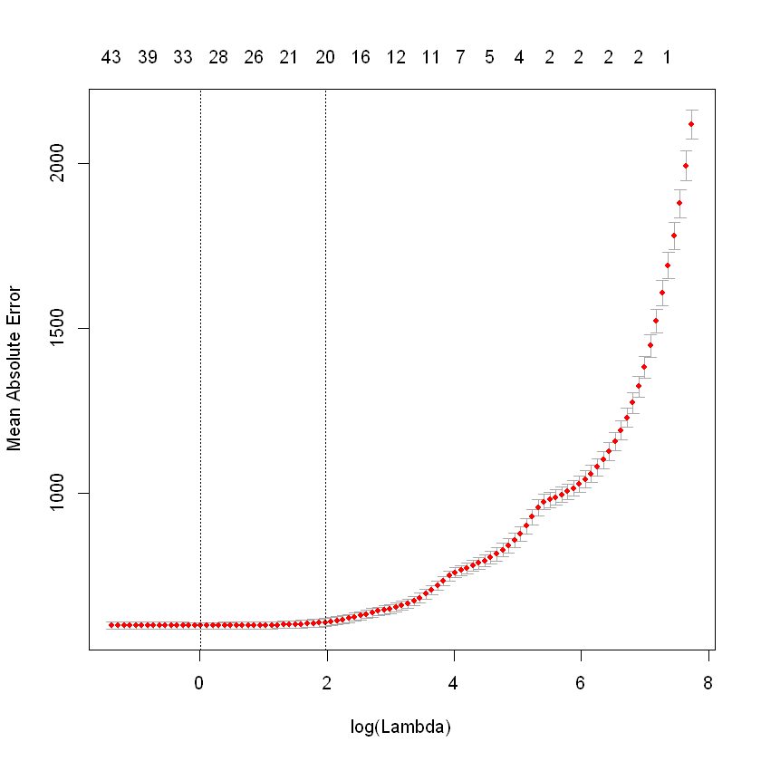

```
[1] "Hour 4"
[1] "Min value for Lambda= 3.00660411585782"
[1] "1se value for Lambda= 9.18173453254706"
49 x 1 sparse Matrix of class "dgCMatrix"
                             1
(Intercept)       1.725107e+03
Lag_day2_hour_0  -5.557449e-01
Lag_day2_hour_1  -2.298094e-01
Lag_day2_hour_2   .
Lag_day2_hour_3   .
Lag_day2_hour_4   6.263802e-01
Lag_day2_hour_5   1.021932e-01
Lag_day2_hour_6   .
Lag_day2_hour_7   1.995943e-01
Lag_day2_hour_8   .
Lag_day2_hour_9  -4.663138e-01
Lag_day2_hour_10 -1.296091e-01
Lag_day2_hour_11 -1.694535e-01
Lag_day2_hour_12  .
Lag_day2_hour_13  3.146706e-01
Lag_day2_hour_14  .
Lag_day2_hour_15  .
Lag_day2_hour_16  1.117374e-02
Lag_day2_hour_17  .
Lag_day2_hour_18  .
Lag_day2_hour_19  .
Lag_day2_hour_20  .
Lag_day2_hour_21  .
Lag_day2_hour_22  3.175510e-01
Lag_day2_hour_23  8.674208e-01
Lag_day7_hour_0   .
Lag_day7_hour_1   .
Lag_day7_hour_2   .
Lag_day7_hour_3   .
Lag_day7_hour_4   .
Lag_day7_hour_5   1.102905e-02
Lag_day7_hour_6   3.511434e-02
Lag_day7_hour_7   2.980120e-01
Lag_day7_hour_8   2.525305e-02
Lag_day7_hour_9   .
Lag_day7_hour_10  .
Lag_day7_hour_11  .
Lag_day7_hour_12  .
Lag_day7_hour_13  3.412838e-03
Lag_day7_hour_14  4.547529e-02
Lag_day7_hour_15  4.597992e-02
Lag_day7_hour_16  .
Lag_day7_hour_17  .
Lag_day7_hour_18 -1.827504e-02
Lag_day7_hour_19 -1.761890e-01
Lag_day7_hour_20 -1.469903e-01
Lag_day7_hour_21  .
Lag_day7_hour_22 -3.979133e-02
Lag_day7_hour_23 -1.797803e-02
[1] "Plot for 4'th hour's Cross Validation"
```

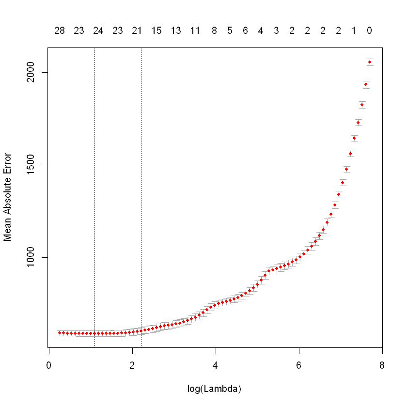

```
[1] "Hour 5"
[1] "Min value for Lambda= 4.49619383147231"
[1] "1se value for Lambda= 12.5109264079849"
49 x 1 sparse Matrix of class "dgCMatrix"
                             1
(Intercept)       1.019161e+03
Lag_day2_hour_0  -4.895879e-01
Lag_day2_hour_1  -3.124841e-01
Lag_day2_hour_2   .
Lag_day2_hour_3   .
Lag_day2_hour_4   .
Lag_day2_hour_5   7.229138e-01
Lag_day2_hour_6   1.396637e-01
Lag_day2_hour_7   7.704330e-02
Lag_day2_hour_8   .
Lag_day2_hour_9  -5.872459e-01
Lag_day2_hour_10  .
Lag_day2_hour_11 -1.029651e-01
Lag_day2_hour_12  .
Lag_day2_hour_13  2.576592e-01
Lag_day2_hour_14  .
Lag_day2_hour_15  .
Lag_day2_hour_16  .
Lag_day2_hour_17  .
Lag_day2_hour_18  .
Lag_day2_hour_19  .
Lag_day2_hour_20  .
Lag_day2_hour_21  .
Lag_day2_hour_22  4.135737e-01
Lag_day2_hour_23  7.535157e-01
Lag_day7_hour_0   .
Lag_day7_hour_1   .
Lag_day7_hour_2  -9.189887e-03
Lag_day7_hour_3   .
Lag_day7_hour_4   .
Lag_day7_hour_5   .
Lag_day7_hour_6   3.322620e-02
Lag_day7_hour_7   3.077563e-01
Lag_day7_hour_8   6.750700e-02
Lag_day7_hour_9   .
Lag_day7_hour_10  .
Lag_day7_hour_11  .
Lag_day7_hour_12  .
Lag_day7_hour_13  .
Lag_day7_hour_14  1.614253e-02
Lag_day7_hour_15  5.061292e-02
Lag_day7_hour_16  .
Lag_day7_hour_17  .
Lag_day7_hour_18  .
Lag_day7_hour_19 -1.371588e-01
Lag_day7_hour_20 -2.842575e-02
Lag_day7_hour_21 -1.181346e-01
Lag_day7_hour_22 -9.302936e-02
Lag_day7_hour_23  .
[1] "Plot for 5'th hour's Cross Validation"
```

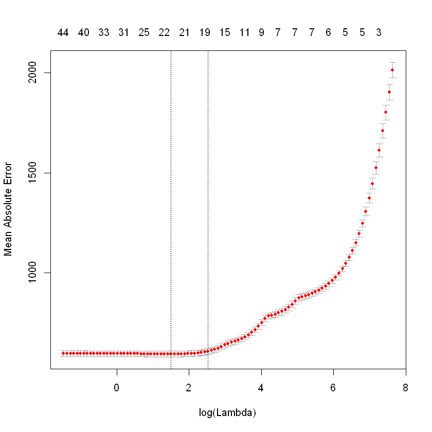

```
[1] "Hour 6"
[1] "Min value for Lambda= 1.00193729522683"
[1] "1se value for Lambda= 12.3523512465609"
49 x 1 sparse Matrix of class "dgCMatrix"
                             1
(Intercept)       1.749760e+03
Lag_day2_hour_0  -5.956721e-01
Lag_day2_hour_1  -2.850100e-01
Lag_day2_hour_2  -2.116887e-01
Lag_day2_hour_3   .
Lag_day2_hour_4   2.390512e-01
Lag_day2_hour_5   3.800029e-01
Lag_day2_hour_6   6.124618e-01
Lag_day2_hour_7   1.371126e-01
Lag_day2_hour_8  -1.912465e-02
Lag_day2_hour_9  -6.988451e-01
Lag_day2_hour_10  .
Lag_day2_hour_11 -1.782031e-01
Lag_day2_hour_12  2.310048e-02
Lag_day2_hour_13  5.705472e-01
Lag_day2_hour_14 -2.155569e-01
Lag_day2_hour_15  1.950122e-04
Lag_day2_hour_16  4.777512e-03
Lag_day2_hour_17  .
Lag_day2_hour_18  .
Lag_day2_hour_19  2.866482e-03
Lag_day2_hour_20  .
Lag_day2_hour_21  1.043735e-01
Lag_day2_hour_22  3.366017e-01
Lag_day2_hour_23  7.398663e-01
Lag_day7_hour_0  -1.411005e-02
Lag_day7_hour_1   .
Lag_day7_hour_2   .
Lag_day7_hour_3   .
Lag_day7_hour_4  -1.971978e-01
Lag_day7_hour_5  -2.063113e-01
Lag_day7_hour_6   2.015240e-01
Lag_day7_hour_7   6.220723e-01
Lag_day7_hour_8   .
Lag_day7_hour_9   .
Lag_day7_hour_10 -1.181716e-06
Lag_day7_hour_11 -3.290241e-02
Lag_day7_hour_12 -9.126085e-02
Lag_day7_hour_13  9.712042e-03
Lag_day7_hour_14  3.114081e-02
Lag_day7_hour_15  2.026772e-01
Lag_day7_hour_16  .
Lag_day7_hour_17 -3.856409e-02
Lag_day7_hour_18 -3.777444e-02
Lag_day7_hour_19  .
Lag_day7_hour_20 -3.975980e-01
Lag_day7_hour_21  .
Lag_day7_hour_22 -5.962188e-03
Lag_day7_hour_23  .
[1] "Plot for 6'th hour's Cross Validation"
```

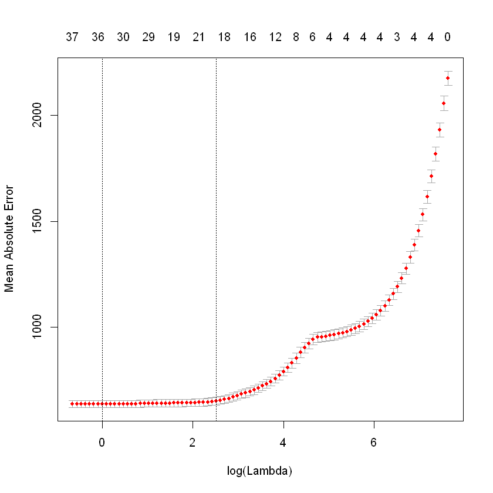

```
[1] "Hour 7"
[1] "Min value for Lambda= 2.82149794876375"
[1] "1se value for Lambda= 9.45653999404346"
49 x 1 sparse Matrix of class "dgCMatrix"
                             1
(Intercept)       2.801575e+03
Lag_day2_hour_0  -6.082141e-01
Lag_day2_hour_1  -2.677989e-01
Lag_day2_hour_2  -1.823681e-01
Lag_day2_hour_3   .
Lag_day2_hour_4   7.247340e-02
Lag_day2_hour_5   7.494439e-01
Lag_day2_hour_6   9.349964e-02
Lag_day2_hour_7   4.377055e-01
Lag_day2_hour_8  -1.492425e-04
Lag_day2_hour_9  -8.320644e-01
Lag_day2_hour_10  .
Lag_day2_hour_11 -1.431174e-01
Lag_day2_hour_12  .
Lag_day2_hour_13  7.420556e-01
Lag_day2_hour_14 -3.304999e-01
Lag_day2_hour_15  .
Lag_day2_hour_16  .
Lag_day2_hour_17 -1.517028e-02
Lag_day2_hour_18  .
Lag_day2_hour_19  .
Lag_day2_hour_20  1.035212e-01
Lag_day2_hour_21  1.241896e-01
Lag_day2_hour_22  2.478438e-01
Lag_day2_hour_23  7.996758e-01
Lag_day7_hour_0  -2.857685e-02
Lag_day7_hour_1   .
Lag_day7_hour_2   .
Lag_day7_hour_3   .
Lag_day7_hour_4  -5.940626e-02
Lag_day7_hour_5  -7.169845e-01
Lag_day7_hour_6   .
Lag_day7_hour_7   1.109575e+00
Lag_day7_hour_8   7.436888e-02
Lag_day7_hour_9   .
Lag_day7_hour_10  .
Lag_day7_hour_11  .
Lag_day7_hour_12 -1.205133e-01
Lag_day7_hour_13  .
Lag_day7_hour_14  .
Lag_day7_hour_15  1.867754e-01
Lag_day7_hour_16  5.254254e-02
Lag_day7_hour_17  .
Lag_day7_hour_18  .
Lag_day7_hour_19 -1.103921e-01
Lag_day7_hour_20 -4.192325e-01
Lag_day7_hour_21  .
Lag_day7_hour_22  .
Lag_day7_hour_23  .
[1] "Plot for 7'th hour's Cross Validation"
```

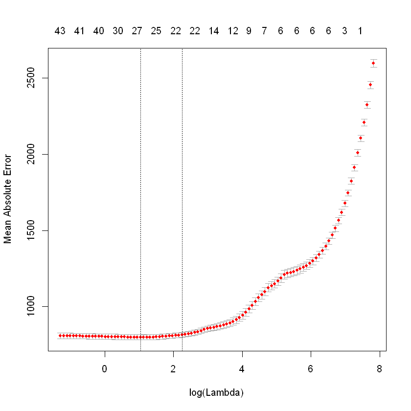

```
[1] "Hour 8"
[1] "Min value for Lambda= 4.98418912002518"
[1] "1se value for Lambda= 15.2209933854307"
49 x 1 sparse Matrix of class "dgCMatrix"
                             1
(Intercept)       4.951590e+03
Lag_day2_hour_0  -1.044158e+00
Lag_day2_hour_1  -9.898787e-02
Lag_day2_hour_2  -2.266860e-01
Lag_day2_hour_3   .
Lag_day2_hour_4   1.480620e-04
Lag_day2_hour_5   1.230309e+00
Lag_day2_hour_6   8.558890e-02
Lag_day2_hour_7   3.234478e-01
Lag_day2_hour_8   .
Lag_day2_hour_9  -9.010697e-01
Lag_day2_hour_10  .
Lag_day2_hour_11 -3.468502e-01
Lag_day2_hour_12  .
Lag_day2_hour_13  1.309836e+00
Lag_day2_hour_14 -6.078237e-01
Lag_day2_hour_15  .
Lag_day2_hour_16  .
Lag_day2_hour_17 -7.455748e-02
Lag_day2_hour_18  .
Lag_day2_hour_19  .
Lag_day2_hour_20  2.296502e-01
Lag_day2_hour_21  1.810867e-01
Lag_day2_hour_22  1.207267e-01
Lag_day2_hour_23  1.029941e+00
Lag_day7_hour_0   .
Lag_day7_hour_1   .
Lag_day7_hour_2   .
Lag_day7_hour_3   .
Lag_day7_hour_4   .
Lag_day7_hour_5  -1.153610e+00
Lag_day7_hour_6   .
Lag_day7_hour_7   7.973589e-01
Lag_day7_hour_8   7.014485e-01
Lag_day7_hour_9   .
Lag_day7_hour_10  .
Lag_day7_hour_11  .
Lag_day7_hour_12 -1.674541e-01
Lag_day7_hour_13  .
Lag_day7_hour_14  .
Lag_day7_hour_15  1.654768e-01
Lag_day7_hour_16  1.845538e-01
Lag_day7_hour_17  .
Lag_day7_hour_18 -4.315439e-02
Lag_day7_hour_19 -2.414868e-01
Lag_day7_hour_20 -4.816942e-01
Lag_day7_hour_21  .
Lag_day7_hour_22  .
Lag_day7_hour_23  .
[1] "Plot for 8'th hour's Cross Validation"
```

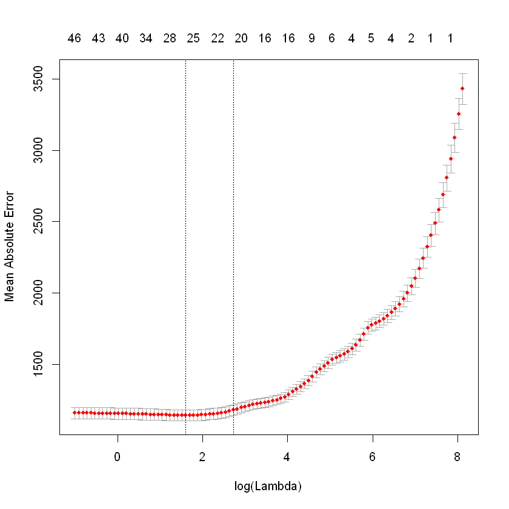

```
[1] "Hour 9"
[1] "Min value for Lambda= 5.03246162903855"
[1] "1se value for Lambda= 15.3684106528531"
49 x 1 sparse Matrix of class "dgCMatrix"
                             1
(Intercept)       6.238115e+03
Lag_day2_hour_0  -1.059918e+00
Lag_day2_hour_1  -1.287285e-01
Lag_day2_hour_2  -3.954999e-01
Lag_day2_hour_3   .
Lag_day2_hour_4   1.496373e-01
Lag_day2_hour_5   1.299628e+00
Lag_day2_hour_6   1.055258e-02
Lag_day2_hour_7   4.733613e-01
Lag_day2_hour_8   .
Lag_day2_hour_9  -1.121795e+00
Lag_day2_hour_10  .
Lag_day2_hour_11 -3.006846e-01
Lag_day2_hour_12  .
Lag_day2_hour_13  1.706640e+00
Lag_day2_hour_14 -8.737146e-01
Lag_day2_hour_15  .
Lag_day2_hour_16  .
Lag_day2_hour_17 -2.836439e-03
Lag_day2_hour_18  .
Lag_day2_hour_19  .
Lag_day2_hour_20  2.481592e-01
Lag_day2_hour_21  6.541238e-02
Lag_day2_hour_22  1.153775e-04
Lag_day2_hour_23  1.243071e+00
Lag_day7_hour_0   .
Lag_day7_hour_1   4.470848e-02
Lag_day7_hour_2   .
Lag_day7_hour_3   .
Lag_day7_hour_4   .
Lag_day7_hour_5  -1.289800e+00
Lag_day7_hour_6   .
Lag_day7_hour_7   6.691874e-01
Lag_day7_hour_8   8.235219e-01
Lag_day7_hour_9   2.462675e-02
Lag_day7_hour_10  .
Lag_day7_hour_11  .
Lag_day7_hour_12 -4.617267e-02
Lag_day7_hour_13  .
Lag_day7_hour_14  .
Lag_day7_hour_15  1.581873e-01
Lag_day7_hour_16  1.724738e-01
Lag_day7_hour_17  .
Lag_day7_hour_18 -9.911936e-02
Lag_day7_hour_19 -2.932835e-01
Lag_day7_hour_20 -5.187378e-01
Lag_day7_hour_21  .
Lag_day7_hour_22  .
Lag_day7_hour_23  4.139786e-02
[1] "Plot for 9'th hour's Cross Validation"
```

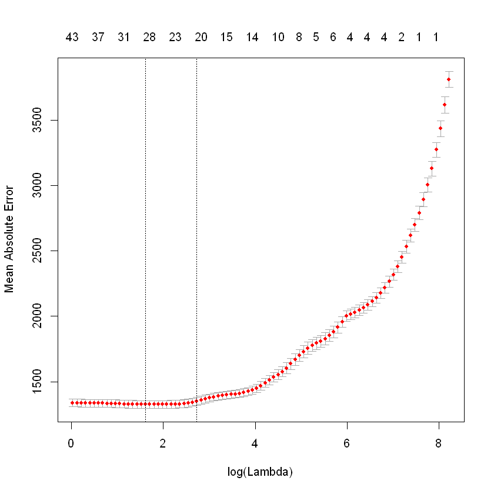

```
[1] "Hour 10"
[1] "Min value for Lambda= 8.53586183319473"
[1] "1se value for Lambda= 19.7189479212926"
49 x 1 sparse Matrix of class "dgCMatrix"
                             1
(Intercept)       6.651159e+03
Lag_day2_hour_0  -7.112966e-01
Lag_day2_hour_1  -1.859685e-01
Lag_day2_hour_2  -3.894575e-01
Lag_day2_hour_3   .
Lag_day2_hour_4   .
Lag_day2_hour_5   1.087873e+00
Lag_day2_hour_6   .
Lag_day2_hour_7   5.330958e-01
Lag_day2_hour_8   .
Lag_day2_hour_9  -1.307624e+00
Lag_day2_hour_10  .
Lag_day2_hour_11 -1.227771e-04
Lag_day2_hour_12  .
Lag_day2_hour_13  1.391807e+00
Lag_day2_hour_14 -6.025803e-01
Lag_day2_hour_15  .
Lag_day2_hour_16  .
Lag_day2_hour_17  .
Lag_day2_hour_18  .
Lag_day2_hour_19  .
Lag_day2_hour_20  1.707213e-01
Lag_day2_hour_21  .
Lag_day2_hour_22  8.650057e-04
Lag_day2_hour_23  1.244481e+00
Lag_day7_hour_0   .
Lag_day7_hour_1   .
Lag_day7_hour_2   .
Lag_day7_hour_3   .
Lag_day7_hour_4   .
Lag_day7_hour_5  -1.060424e+00
Lag_day7_hour_6   .
Lag_day7_hour_7   4.607611e-01
Lag_day7_hour_8   5.617246e-01
Lag_day7_hour_9   2.834871e-01
Lag_day7_hour_10  3.254309e-03
Lag_day7_hour_11  .
Lag_day7_hour_12  .
Lag_day7_hour_13  .
Lag_day7_hour_14  .
Lag_day7_hour_15  1.645295e-01
Lag_day7_hour_16  6.307803e-02
Lag_day7_hour_17  .
Lag_day7_hour_18  .
Lag_day7_hour_19 -3.804076e-01
Lag_day7_hour_20 -3.840837e-01
Lag_day7_hour_21  .
Lag_day7_hour_22  .
Lag_day7_hour_23  .
[1] "Plot for 10'th hour's Cross Validation"
```

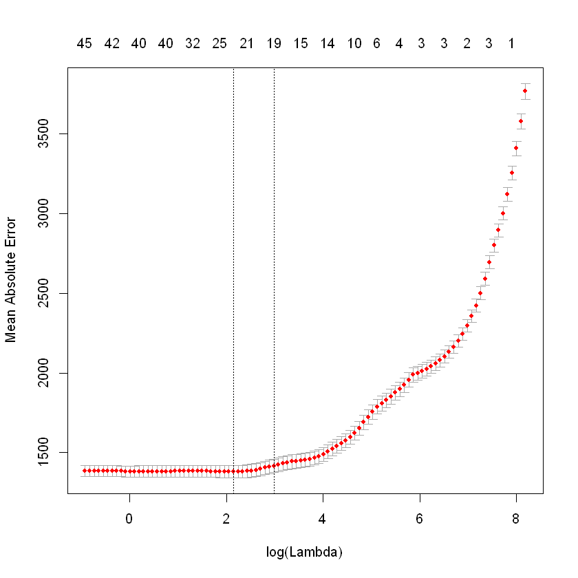

```
[1] "Hour 11"
[1] "Min value for Lambda= 7.65060365654641"
[1] "1se value for Lambda= 21.2882591167938"
49 x 1 sparse Matrix of class "dgCMatrix"
                             1
(Intercept)       7.159033e+03
Lag_day2_hour_0  -7.252933e-01
Lag_day2_hour_1  -2.351743e-01
Lag_day2_hour_2  -3.694814e-01
Lag_day2_hour_3   .
Lag_day2_hour_4   .
Lag_day2_hour_5   1.103015e+00
Lag_day2_hour_6   .
Lag_day2_hour_7   6.066261e-01
Lag_day2_hour_8  -6.256839e-02
Lag_day2_hour_9  -1.339216e+00
Lag_day2_hour_10  .
Lag_day2_hour_11 -6.459095e-05
Lag_day2_hour_12  .
Lag_day2_hour_13  1.518734e+00
Lag_day2_hour_14 -6.358505e-01
Lag_day2_hour_15  .
Lag_day2_hour_16  .
Lag_day2_hour_17  .
Lag_day2_hour_18  .
Lag_day2_hour_19  .
Lag_day2_hour_20  6.315826e-02
Lag_day2_hour_21  .
Lag_day2_hour_22  .
Lag_day2_hour_23  1.317446e+00
Lag_day7_hour_0   .
Lag_day7_hour_1   .
Lag_day7_hour_2   .
Lag_day7_hour_3   .
Lag_day7_hour_4   .
Lag_day7_hour_5  -1.013440e+00
Lag_day7_hour_6   .
Lag_day7_hour_7   4.111574e-01
Lag_day7_hour_8   5.319322e-01
Lag_day7_hour_9   1.955853e-01
Lag_day7_hour_10  4.840881e-02
Lag_day7_hour_11  .
Lag_day7_hour_12  .
Lag_day7_hour_13  .
Lag_day7_hour_14  .
Lag_day7_hour_15  2.644822e-01
Lag_day7_hour_16  7.431983e-03
Lag_day7_hour_17  .
Lag_day7_hour_18 -1.574168e-04
Lag_day7_hour_19 -4.491980e-01
Lag_day7_hour_20 -2.827375e-01
Lag_day7_hour_21  .
Lag_day7_hour_22  .
Lag_day7_hour_23  .
[1] "Plot for 11'th hour's Cross Validation"
```

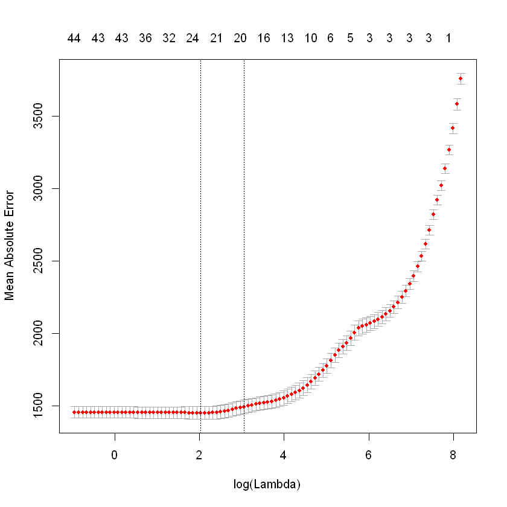

```
[1] "Hour 12"
[1] "Min value for Lambda= 2.76062901361623"
[1] "1se value for Lambda= 13.4238389838118"
49 x 1 sparse Matrix of class "dgCMatrix"
                             1
(Intercept)       5.729510e+03
Lag_day2_hour_0  -8.286437e-01
Lag_day2_hour_1  -2.241796e-01
Lag_day2_hour_2  -4.743517e-01
Lag_day2_hour_3  -2.264203e-01
Lag_day2_hour_4   3.409439e-01
Lag_day2_hour_5   1.157508e+00
Lag_day2_hour_6   .
Lag_day2_hour_7   8.547851e-01
Lag_day2_hour_8  -3.880451e-01
Lag_day2_hour_9  -1.191282e+00
Lag_day2_hour_10  .
Lag_day2_hour_11 -3.809638e-02
Lag_day2_hour_12  7.058721e-02
Lag_day2_hour_13  1.727348e+00
Lag_day2_hour_14 -9.030351e-01
Lag_day2_hour_15  .
Lag_day2_hour_16  .
Lag_day2_hour_17  2.885936e-02
Lag_day2_hour_18  1.427745e-01
Lag_day2_hour_19  .
Lag_day2_hour_20 -1.817045e-04
Lag_day2_hour_21  .
Lag_day2_hour_22  .
Lag_day2_hour_23  1.189442e+00
Lag_day7_hour_0   6.813142e-02
Lag_day7_hour_1   3.092875e-01
Lag_day7_hour_2   .
Lag_day7_hour_3   .
Lag_day7_hour_4  -5.238622e-02
Lag_day7_hour_5  -1.189753e+00
Lag_day7_hour_6  -2.168155e-01
Lag_day7_hour_7   6.086716e-01
Lag_day7_hour_8   3.618598e-01
Lag_day7_hour_9   1.135458e-01
Lag_day7_hour_10  .
Lag_day7_hour_11  .
Lag_day7_hour_12  .
Lag_day7_hour_13  1.340531e-01
Lag_day7_hour_14  .
Lag_day7_hour_15  1.248243e-01
Lag_day7_hour_16  1.574468e-01
Lag_day7_hour_17  3.623081e-02
Lag_day7_hour_18 -3.199677e-01
Lag_day7_hour_19 -2.858463e-01
Lag_day7_hour_20 -2.974244e-01
Lag_day7_hour_21  2.138392e-02
Lag_day7_hour_22  .
Lag_day7_hour_23  1.688499e-01
[1] "Plot for 12'th hour's Cross Validation"
```

[12 more figures not shown]

```r
for(i in seq(0,23,by=1)){
    plot(get(paste0("cvfit",i)))
    print(paste("Hour",i))
    print(paste("Min value for Lambda=",get(paste0("cvfit",i))$lambda.min))
    print(paste("1se value for Lambda=",get(paste0("cvfit",i))$lambda.1se))
    print(coef(get(paste0("cvfit",i)), s = 'lambda.min'))
    print(paste0("Plot for ",i,"'th hour's Cross Validation"))
}
```

```r
test_mat0=as.matrix(test_d0[complete.cases(test_d0),-c('date',"hour","consumption")])
test_mat1=as.matrix(test_d1[complete.cases(test_d1),-c('date',"hour","consumption")])
test_mat2=as.matrix(test_d2[complete.cases(test_d2),-c('date',"hour","consumption")])
test_mat3=as.matrix(test_d3[complete.cases(test_d3),-c('date',"hour","consumption")])
test_mat4=as.matrix(test_d4[complete.cases(test_d4),-c('date',"hour","consumption")])
test_mat5=as.matrix(test_d5[complete.cases(test_d5),-c('date',"hour","consumption")])
test_mat6=as.matrix(test_d6[complete.cases(test_d6),-c('date',"hour","consumption")])
test_mat7=as.matrix(test_d7[complete.cases(test_d7),-c('date',"hour","consumption")])
test_mat8=as.matrix(test_d8[complete.cases(test_d8),-c('date',"hour","consumption")])
test_mat9=as.matrix(test_d9[complete.cases(test_d9),-c('date',"hour","consumption")])
test_mat10=as.matrix(test_d10[complete.cases(test_d10),-c('date',"hour","consumption")])
test_mat11=as.matrix(test_d11[complete.cases(test_d11),-c('date',"hour","consumption")])
test_mat12=as.matrix(test_d12[complete.cases(test_d12),-c('date',"hour","consumption")])
test_mat13=as.matrix(test_d13[complete.cases(test_d13),-c('date',"hour","consumption")])
test_mat14=as.matrix(test_d14[complete.cases(test_d14),-c('date',"hour","consumption")])
test_mat15=as.matrix(test_d15[complete.cases(test_d15),-c('date',"hour","consumption")])
test_mat16=as.matrix(test_d16[complete.cases(test_d16),-c('date',"hour","consumption")])
test_mat17=as.matrix(test_d17[complete.cases(test_d17),-c('date',"hour","consumption")])
test_mat18=as.matrix(test_d18[complete.cases(test_d18),-c('date',"hour","consumption")])
test_mat19=as.matrix(test_d19[complete.cases(test_d19),-c('date',"hour","consumption")])
test_mat20=as.matrix(test_d20[complete.cases(test_d20),-c('date',"hour","consumption")])
test_mat21=as.matrix(test_d21[complete.cases(test_d21),-c('date',"hour","consumption")])
test_mat22=as.matrix(test_d22[complete.cases(test_d22),-c('date',"hour","consumption")])
test_mat23=as.matrix(test_d23[complete.cases(test_d23),-c('date',"hour","consumption")])
```

```r
lasso_model0 <- glmnet(train_mat0,result_vec0, alpha = 1, lambda = cvfit0$lambda.min, standardize = FALSE)
lasso_model1 <- glmnet(train_mat1,result_vec1, alpha = 1, lambda = cvfit1$lambda.min, standardize = FALSE)
lasso_model2 <- glmnet(train_mat2,result_vec2, alpha = 1, lambda = cvfit2$lambda.min, standardize = FALSE)
lasso_model3 <- glmnet(train_mat3,result_vec3, alpha = 1, lambda = cvfit3$lambda.min, standardize = FALSE)
lasso_model4 <- glmnet(train_mat4,result_vec4, alpha = 1, lambda = cvfit4$lambda.min, standardize = FALSE)
lasso_model5 <- glmnet(train_mat5,result_vec5, alpha = 1, lambda = cvfit5$lambda.min, standardize = FALSE)
lasso_model6 <- glmnet(train_mat6,result_vec6, alpha = 1, lambda = cvfit6$lambda.min, standardize = FALSE)
lasso_model7 <- glmnet(train_mat7,result_vec7, alpha = 1, lambda = cvfit7$lambda.min, standardize = FALSE)
lasso_model8 <- glmnet(train_mat8,result_vec8, alpha = 1, lambda = cvfit8$lambda.min, standardize = FALSE)
lasso_model9 <- glmnet(train_mat9,result_vec9, alpha = 1, lambda = cvfit9$lambda.min, standardize = FALSE)
lasso_model10 <- glmnet(train_mat10,result_vec10, alpha = 1, lambda = cvfit10$lambda.min, standardize = FALSE)
lasso_model11 <- glmnet(train_mat11,result_vec11, alpha = 1, lambda = cvfit11$lambda.min, standardize = FALSE)
lasso_model12 <- glmnet(train_mat12,result_vec12, alpha = 1, lambda = cvfit12$lambda.min, standardize = FALSE)
lasso_model13 <- glmnet(train_mat13,result_vec13, alpha = 1, lambda = cvfit13$lambda.min, standardize = FALSE)
lasso_model14 <- glmnet(train_mat14,result_vec14, alpha = 1, lambda = cvfit14$lambda.min, standardize = FALSE)
lasso_model15 <- glmnet(train_mat15,result_vec15, alpha = 1, lambda = cvfit15$lambda.min, standardize = FALSE)
lasso_model16 <- glmnet(train_mat16,result_vec16, alpha = 1, lambda = cvfit16$lambda.min, standardize = FALSE)
lasso_model17 <- glmnet(train_mat17,result_vec17, alpha = 1, lambda = cvfit17$lambda.min, standardize = FALSE)
lasso_model18 <- glmnet(train_mat18,result_vec18, alpha = 1, lambda = cvfit18$lambda.min, standardize = FALSE)
lasso_model19 <- glmnet(train_mat19,result_vec19, alpha = 1, lambda = cvfit19$lambda.min, standardize = FALSE)
lasso_model20 <- glmnet(train_mat20,result_vec20, alpha = 1, lambda = cvfit20$lambda.min, standardize = FALSE)
lasso_model21 <- glmnet(train_mat21,result_vec21, alpha = 1, lambda = cvfit21$lambda.min, standardize = FALSE)
lasso_model22 <- glmnet(train_mat22,result_vec22, alpha = 1, lambda = cvfit22$lambda.min, standardize = FALSE)
lasso_model23 <- glmnet(train_mat23,result_vec23, alpha = 1, lambda = cvfit23$lambda.min, standardize = FALSE)
```

```r
predicts_hour0 <- predict(lasso_model0, s = cvfit0$lambda.min, newx = test_mat0)
predicts_hour1 <- predict(lasso_model1, s = cvfit1$lambda.min, newx = test_mat1)
predicts_hour2 <- predict(lasso_model2, s = cvfit2$lambda.min, newx = test_mat2)
predicts_hour3 <- predict(lasso_model3, s = cvfit3$lambda.min, newx = test_mat3)
predicts_hour4 <- predict(lasso_model4, s = cvfit4$lambda.min, newx = test_mat4)
predicts_hour5 <- predict(lasso_model5, s = cvfit5$lambda.min, newx = test_mat5)
predicts_hour6 <- predict(lasso_model6, s = cvfit6$lambda.min, newx = test_mat6)
predicts_hour7 <- predict(lasso_model7, s = cvfit7$lambda.min, newx = test_mat7)
predicts_hour8 <- predict(lasso_model8, s = cvfit8$lambda.min, newx = test_mat8)
predicts_hour9 <- predict(lasso_model9, s = cvfit9$lambda.min, newx = test_mat9)
predicts_hour10 <- predict(lasso_model10, s = cvfit10$lambda.min, newx = test_mat10)
predicts_hour11 <- predict(lasso_model11, s = cvfit11$lambda.min, newx = test_mat11)
predicts_hour12 <- predict(lasso_model12, s = cvfit12$lambda.min, newx = test_mat12)
predicts_hour13 <- predict(lasso_model13, s = cvfit13$lambda.min, newx = test_mat13)
predicts_hour14 <- predict(lasso_model14, s = cvfit14$lambda.min, newx = test_mat14)
predicts_hour15 <- predict(lasso_model15, s = cvfit15$lambda.min, newx = test_mat15)
predicts_hour16 <- predict(lasso_model16, s = cvfit16$lambda.min, newx = test_mat16)
predicts_hour17 <- predict(lasso_model17, s = cvfit17$lambda.min, newx = test_mat17)
predicts_hour18 <- predict(lasso_model18, s = cvfit18$lambda.min, newx = test_mat18)
predicts_hour19 <- predict(lasso_model19, s = cvfit19$lambda.min, newx = test_mat19)
predicts_hour20 <- predict(lasso_model20, s = cvfit20$lambda.min, newx = test_mat20)
predicts_hour21 <- predict(lasso_model21, s = cvfit21$lambda.min, newx = test_mat21)
predicts_hour22 <- predict(lasso_model22, s = cvfit22$lambda.min, newx = test_mat22)
predicts_hour23 <- predict(lasso_model23, s = cvfit23$lambda.min, newx = test_mat23)
```

```r
mape_result_d[1] <- MAPE(test_d0$consumption, predicts_hour0)
mape_result_d[2] <- MAPE(test_d1$consumption, predicts_hour1)
mape_result_d[3] <- MAPE(test_d2$consumption, predicts_hour2)
mape_result_d[4] <- MAPE(test_d3$consumption, predicts_hour3)
mape_result_d[5] <- MAPE(test_d4$consumption, predicts_hour4)
mape_result_d[6] <- MAPE(test_d5$consumption, predicts_hour5)
mape_result_d[7] <- MAPE(test_d6$consumption, predicts_hour6)
mape_result_d[8] <- MAPE(test_d7$consumption, predicts_hour7)
mape_result_d[9] <- MAPE(test_d8$consumption, predicts_hour8)
mape_result_d[10] <- MAPE(test_d9$consumption, predicts_hour9)
mape_result_d[11] <- MAPE(test_d10$consumption, predicts_hour10)
mape_result_d[12] <- MAPE(test_d11$consumption, predicts_hour11)
mape_result_d[13] <- MAPE(test_d12$consumption, predicts_hour12)
mape_result_d[14] <- MAPE(test_d13$consumption, predicts_hour13)
mape_result_d[15] <- MAPE(test_d14$consumption, predicts_hour14)
mape_result_d[16] <- MAPE(test_d15$consumption, predicts_hour15)
mape_result_d[17] <- MAPE(test_d16$consumption, predicts_hour16)
mape_result_d[18] <- MAPE(test_d17$consumption, predicts_hour17)
mape_result_d[19] <- MAPE(test_d18$consumption, predicts_hour18)
mape_result_d[20] <- MAPE(test_d19$consumption, predicts_hour19)
mape_result_d[21] <- MAPE(test_d20$consumption, predicts_hour20)
mape_result_d[22] <- MAPE(test_d21$consumption, predicts_hour21)
mape_result_d[23] <- MAPE(test_d22$consumption, predicts_hour22)
mape_result_d[24] <- MAPE(test_d23$consumption, predicts_hour23)
#mape_result_d
```

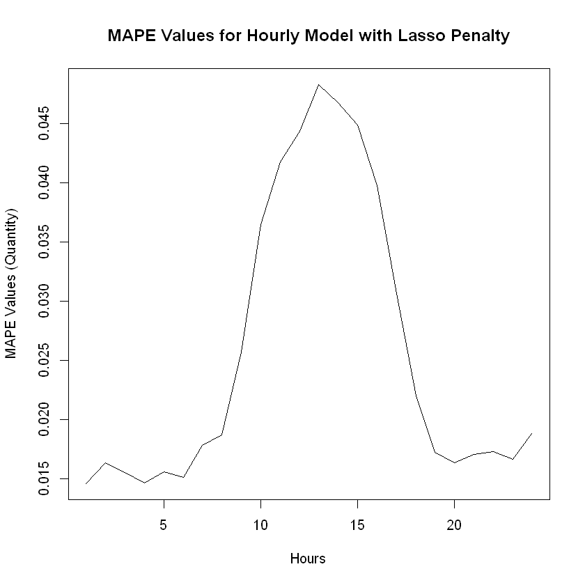

```r
plot(mape_result_d,type="l",ylab="MAPE Values (Quantity)",xlab="Hours",main="MAPE Values for Hourly Model with Lasso Penalty")
```

```r
MAPE0d_reg_values=as.vector(abs(((hour0_test$consumption-predicts_hour0)/predicts_hour0)))
MAPE1d_reg_values=as.vector(abs(((hour1_test$consumption-predicts_hour1)/predicts_hour1)))
MAPE2d_reg_values=as.vector(abs(((hour2_test$consumption-predicts_hour2)/predicts_hour2)))
MAPE3d_reg_values=as.vector(abs(((hour3_test$consumption-predicts_hour3)/predicts_hour3)))
MAPE4d_reg_values=as.vector(abs(((hour4_test$consumption-predicts_hour4)/predicts_hour4)))
MAPE5d_reg_values=as.vector(abs(((hour5_test$consumption-predicts_hour5)/predicts_hour5)))
MAPE6d_reg_values=as.vector(abs(((hour6_test$consumption-predicts_hour6)/predicts_hour6)))
MAPE7d_reg_values=as.vector(abs(((hour7_test$consumption-predicts_hour7)/predicts_hour7)))
MAPE8d_reg_values=as.vector(abs(((hour8_test$consumption-predicts_hour8)/predicts_hour8)))
MAPE9d_reg_values=as.vector(abs(((hour9_test$consumption-predicts_hour9)/predicts_hour9)))
MAPE10d_reg_values=as.vector(abs(((hour10_test$consumption-predicts_hour10)/predicts_hour10)))
MAPE11d_reg_values=as.vector(abs(((hour11_test$consumption-predicts_hour11)/predicts_hour11)))
MAPE12d_reg_values=as.vector(abs(((hour12_test$consumption-predicts_hour12)/predicts_hour12)))
MAPE13d_reg_values=as.vector(abs(((hour13_test$consumption-predicts_hour13)/predicts_hour13)))
MAPE14d_reg_values=as.vector(abs(((hour14_test$consumption-predicts_hour14)/predicts_hour14)))
MAPE15d_reg_values=as.vector(abs(((hour15_test$consumption-predicts_hour15)/predicts_hour15)))
MAPE16d_reg_values=as.vector(abs(((hour16_test$consumption-predicts_hour16)/predicts_hour16)))
MAPE17d_reg_values=as.vector(abs(((hour17_test$consumption-predicts_hour17)/predicts_hour17)))
MAPE18d_reg_values=as.vector(abs(((hour18_test$consumption-predicts_hour18)/predicts_hour18)))
MAPE19d_reg_values=as.vector(abs(((hour19_test$consumption-predicts_hour19)/predicts_hour19)))
MAPE20d_reg_values=as.vector(abs(((hour20_test$consumption-predicts_hour20)/predicts_hour20)))
MAPE21d_reg_values=as.vector(abs(((hour21_test$consumption-predicts_hour21)/predicts_hour21)))
MAPE22d_reg_values=as.vector(abs(((hour22_test$consumption-predicts_hour22)/predicts_hour22)))
MAPE23d_reg_values=as.vector(abs(((hour23_test$consumption-predicts_hour23)/predicts_hour23)))
```

```r
D_all_val=c(MAPE0d_reg_values,MAPE1d_reg_values,MAPE2d_reg_values,MAPE3d_reg_values,MAPE4d_reg_values,MAPE5d_reg_values,
           MAPE6d_reg_values,MAPE7d_reg_values,MAPE8d_reg_values,MAPE9d_reg_values,MAPE10d_reg_values,MAPE11d_reg_values,
           MAPE12d_reg_values,MAPE13d_reg_values,MAPE14d_reg_values,MAPE15d_reg_values,MAPE16d_reg_values,MAPE17d_reg_values,
           MAPE18d_reg_values,MAPE19d_reg_values,MAPE20d_reg_values,MAPE21d_reg_values,MAPE22d_reg_values,MAPE23d_reg_values)
```

## General Summary Statistic for Hourly Model with Lasso Penalty

```r
summary(D_all_val)
```

```
     Min.   1st Qu.    Median      Mean   3rd Qu.      Max.
0.0001601 0.0085149 0.0171214 0.0255044 0.0321593 0.1574406
```

## Results of Lasso Models

When lambda version is determined as min, both lags' values become important. Namely, both lags have significant role to predict the consumption. In the cv.glmnet "measure.type" is determined as "mae", which caused from fixed loss function type. In other words, model objective must be determined in terms of fixed loss type. How many features were selected for model depends on the hour, but in general number of features is arranged in between 40 to 15. Also, lambda values are also varied between the hourly models. In general it is hard to say that there are fixed number of selected number of features and values of lambda for all hours. However, there are similar models for different hours. These models have the same significant parameters and similar coefficients for these parameters. It's hard to observe that but similar models are sequent hour models in general.

Moreover, it can be said that prediction performance is similar to predictions without the lasso penalty in terms of hourly results. So, it can be said that predicting midday consumption is harder than midnight, which can be caused by the volume of the deviation in consumption values that differs for different hours.

Lastly, the performance of the Lasso model was evaluated at the end of homework, which enables us to observe the difference and actual performance of the model by comparing the other models. So, the performance of the Lasso Model can be found at the end of Homework.

# Part F

The obtained averages of MAPE values are one of the good indicators for performance. So all the mean of MAPE values for each part displayed as follows:

```r
MAPE_hourly=(MAPE_0+MAPE_1+MAPE_2+MAPE_3+MAPE_4+MAPE_5+MAPE_6+MAPE_7+MAPE_8+MAPE_9+
            MAPE_10+MAPE_11+MAPE_12+MAPE_13+MAPE_14+MAPE_15+MAPE_16+MAPE_17+MAPE_18+MAPE_19+
            MAPE_20+MAPE_21+MAPE_22+MAPE_23)/24


print(paste("MAPE values for Lag_48 results(PART A):",MAPE_48))
print(paste("MAPE values for Lag_168 results(PART A):",MAPE_168))
print(paste("MAPE values for Regression Model:",MAPE_reg))
print(paste("MAPE values(average of all hour) for hourly results(PART C):",MAPE_hourly))
print(paste("MAPE values for Part D results(PART D):",mean(mape_result_d)))
```

```
[1] "MAPE values for Lag_48 results(PART A): 0.0818808509914842"
[1] "MAPE values for Lag_168 results(PART A): 0.0365111250910964"
[1] "MAPE values for Regression Model: 0.0423023288459373"
[1] "MAPE values(average of all hour) for hourly results(PART C): 0.0435844962464306"
[1] "MAPE values for Part D results(PART D): 0.0255043860515335"
```

```r
MAPE_dt=data.table("MAPE of Lag 48"=MAPE_48_values,"MAPE of Lag 168"=MAPE_168_values,"MAPE of Regr."=MAPE_reg_values,"MAPE of Seasonality"=C_all_val ,"MAPE of Lasso"=D_all_val)
melted_dt=melt(MAPE_dt)
```

For understanding the statistical features of the obtained errors for each part, a data table is added. In this data table, it can be observed min, max, quartiles, and standard deviation of each part's errors. Similar information can also be achieved in the boxplot, but in order to get precise values, the data table is much more convenient and useful.

### Summary Table for Errors

```r
feature_summary=melted_dt[,list("Average Mape"=mean(value),Minimum=min(value),"Lower Quartile"=quantile(value)[2],
                             "Upper Quartile"=quantile(value)[4],Maximum=max(value),"Standard Deviation"=sd(value))
                               ,by=list(variable)]
feature_summary
```

| variable | Average Mape | Minimum | Lower Quartile | Upper Quartile | Maximum | Standard Deviation |
| --- | --- | --- | --- | --- | --- | --- |
| MAPE of Lag 48 | 0.08188085 | 9.546393e-05 | 0.016631012 | 0.10403641 | 0.4467156 | 0.08754893 |
| MAPE of Lag 168 | 0.03651113 | 8.522179e-05 | 0.013539404 | 0.04765597 | 0.2432434 | 0.03555525 |
| MAPE of Regr. | 0.04230233 | 3.668726e-05 | 0.018270815 | 0.05706363 | 0.1661240 | 0.03378905 |
| MAPE of Seasonality | 0.04358450 | 4.843149e-04 | 0.021602144 | 0.05906268 | 0.1656688 | 0.03063277 |
| MAPE of Lasso | 0.02550439 | 1.601431e-04 | 0.008514905 | 0.03215926 | 0.1574406 | 0.02705346 |

### Boxplot for Obtained Results

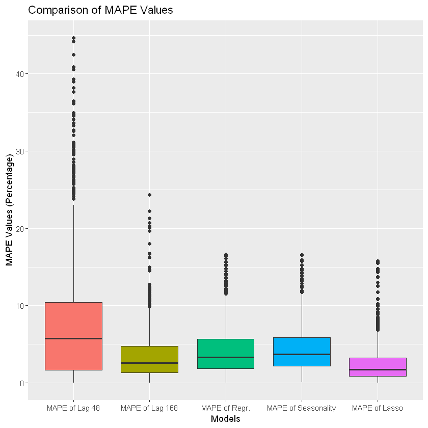

```r
ggplot(melted_dt,aes(x=variable,y=value*100,fill=variable))+geom_boxplot(position=position_dodge())+
        theme(legend.position = "none")+ggtitle("Comparison of MAPE Values")+xlab("Models")+ylab("MAPE Values (Percentage)")
```

## Final Thoughts

In the beginning, it can be said that consumption values from 1 week before are much useful for predicting the consumption which must be caused by similar consumption patterns for week's days. Namely, consumption's volume depends on which day is of the week because similar tasks are performed on the same days. In addition, Lag 168 is a good predictor for naive approach.

It is hard to say that the Lag 48 Model is a good naive approach for prediction. In general, consumption of weekdays and weekends differs a lot. However, the Weekend's consumption is predicted by using Thursday and Friday consumption values which are irrelevant to the consumption pattern on weekends in the Lag 48 Model.

The biggest difference for the Seasonality model is the increased number of features for each model. But, much as there is an increase in the number of features, all models have a small input size to train the model. So, it may hard to establish a good predictor for consumption with the limited dataset. However, the maximum value of the error decreased in this model compared to the Regression Model. In addition, the Mean absolute error increased in this model, which is one of the deficits for this model.

Finally, the best model achieved by the Lasso model. This model is the best in terms of both mean absolute error and the maximum value of absolute error. Input size must be the key factor for understanding the improvement between the seasonality model and lasso model. If models have limited input, coefficients tend to become big numbers for fitting the training set. Namely, the training set doesn't have enough data to represent all the cases for consumption, which caused overfitting for the training model. By applying the lasso function, the over-fitting problem was discarded and a decrease is achieved in generalization errors(in test set prediction).